# On the waning of forms - a corpus-based analysis of losers in language change (Part 4)

Martin Schweinberger

2021-05-17

[figure not shown]

This document documents the analysis of the adjective amplifier *really* in New Zealand English. The analysis was performed with the aim of fitting a generalized-linear binomial logistic mixed-effects regression to explain which factors correlate with the use of *really* and to ascertain if

1. *really* is increasing across apparent time
2. if the increase of *really* is systematic or layered (which would imply that the use of *really* is stratified along linguistic and social lines) or unsystematic (which would imply that it correlates with few if any linguistic or social variables).

# 1 Introduction

We will now begin with the analysis. In a first step, the session is prepared by setting options and activating packages.

```r
# load packages
library(tidyverse)
library(tidyr)
# set options
options(stringsAsFactors = F)
options(scipen = 999)
options(max.print=10000)
```

We proceed by loading the data, factorizing variables that are so far represented as character strings instead of factors, and inspecting its characteristics.

```r
# load data
reallywsc <- read.delim(here::here("data", "ampwsc_regdat.txt"), sep = "\t", header = T, skipNul = T)
# remove superfluous variables
reallywsc <- reallywsc %>%
    dplyr::filter(Variant != "0") %>%
  dplyr::select(-ID, -FileSpeaker, -Speaker, -very, -File, -Age_original) %>%
  # convert to title format
  dplyr::mutate(really = ifelse(Variant == "really", "really", "other"),
                Ethnicity = stringr::str_to_title(Ethnicity),
                L1 = stringr::str_to_title(L1),
                Emotionality = stringr::str_to_title(Emotionality)) %>%
  # remove variant column
  dplyr::select(-Variant) %>%
  # convert charaters to factors
  dplyr::mutate_if(is.character, factor)
# inspect data
nrow(reallywsc); str(reallywsc); head(reallywsc); summary (reallywsc)
```

```
## [1] 2344
```

```
## 'data.frame':    2344 obs. of  14 variables:
##  $ Adjective       : Factor w/ 420 levels "able","absurd",..: 158 87 87 147 127 247 82 308 295 391 ...
##  $ Ethnicity       : Factor w/ 4 levels "Maori","Maori/Pakeha",..: 4 4 4 4 4 4 4 4 4 4 ...
##  $ Gender          : Factor w/ 2 levels "Man","Woman": 2 2 2 2 1 1 1 1 1 1 ...
##  $ Age             : Factor w/ 6 levels "16-19","20-29",..: 4 4 4 4 2 2 2 2 2 2 ...
##  $ Education       : Factor w/ 2 levels "NoUniversity",..: 2 2 2 2 1 1 1 1 1 1 ...
##  $ L1              : Factor w/ 2 levels "English","Other": 1 1 1 1 1 1 1 1 1 1 ...
##  $ Type            : Factor w/ 14 levels "BroadcastInterview",..: 9 9 9 9 9 9 9 9 9 9 ...
##  $ Frequency       : num  0.4401 0.0994 0.0994 0.2698 0.0515 ...
##  $ Function        : Factor w/ 2 levels "Attributive",..: 2 1 1 1 2 1 1 2 2 2 ...
##  $ Priming         : Factor w/ 2 levels "NoPrime","Prime": 1 1 1 1 1 1 1 1 1 1 ...
##  $ Gradability     : num  0.13 -3.664 0.639 -2.874 1 ...
##  $ SemanticCategory: Factor w/ 9 levels "Color","Difficulty",..: 2 4 4 4 5 5 4 3 6 4 ...
##  $ Emotionality    : Factor w/ 3 levels "Negative","Neutral",..: 2 1 1 2 3 2 3 2 2 1 ...
##  $ really          : Factor w/ 2 levels "other","really": 2 1 1 1 1 1 1 1 1 1 ...
```

```
##     Adjective Ethnicity Gender   Age    Education      L1          Type
## 1        hard    Pakeha  Woman 40-49   University English RadioTalkback
## 2   desperate    Pakeha  Woman 40-49   University English RadioTalkback
## 3   desperate    Pakeha  Woman 40-49   University English RadioTalkback
## 4       funny    Pakeha  Woman 40-49   University English RadioTalkback
## 5 fascinating    Pakeha    Man 20-29 NoUniversity English RadioTalkback
## 6  outrageous    Pakeha    Man 20-29 NoUniversity English RadioTalkback
##   Frequency    Function Priming Gradability SemanticCategory Emotionality
## 1   0.44015 Predicative NoPrime   0.1299883       Difficulty      Neutral
## 2   0.09939 Attributive NoPrime  -3.6635616  HumanPropensity     Negative
## 3   0.09939 Attributive NoPrime   0.6389904  HumanPropensity     Negative
## 4   0.26977 Attributive NoPrime  -2.8740838  HumanPropensity      Neutral
## 5   0.05153 Predicative NoPrime   1.0000000            Other     Positive
## 6   0.10307 Attributive NoPrime  -0.2669646            Other      Neutral
##   really
## 1 really
## 2  other
## 3  other
## 4  other
## 5  other
## 6  other
```

```
##    Adjective           Ethnicity      Gender        Age
##  good   : 417   Maori       : 224   Man  : 929   16-19:340
##  nice   : 137   Maori/Pakeha:  79   Woman:1415   20-29:948
##  hard   :  80   Other       : 219                30-39:320
##  funny  :  77   Pakeha      :1822                40-49:414
##  bad    :  71                                    50-59:208
##  cool   :  54                                    60+  :114
##  (Other):1508
##         Education          L1                            Type
##  NoUniversity:1180   English:2150   Conversation           :1612
##  University  :1164   Other  : 194   TelephoneConversation  : 186
##                                     BroadcastInterview     : 154
##                                     TransactionsAndMeetings: 152
##                                     RadioTalkback          :  55
##                                     SportsCommentary       :  53
##                                     (Other)                : 132
##    Frequency              Function       Priming      Gradability
##  Min.   :0.00943   Attributive:1326   NoPrime:1946   Min.   :-3.6636
##  1st Qu.:0.09471   Predicative:1018   Prime  : 398   1st Qu.:-3.2837
##  Median :0.31969                                     Median :-1.0586
##  Mean   :1.41350                                     Mean   :-1.2369
##  3rd Qu.:1.32536                                     3rd Qu.: 0.5163
##  Max.   :6.89038                                     Max.   : 3.6634
##
##          SemanticCategory   Emotionality     really
##  HumanPropensity :798     Negative: 392   other :1493
##  Value           :762     Neutral :1115   really: 851
##  Other           :241     Positive: 837
##  Difficulty      :179
##  Dimension       :152
##  PhysicalProperty:145
##  (Other)         : 67
```

We will now scale numeric variables so that the estimates refer to the mean of the numeric variables rather than their true 0-point. This is necessary as estimates for adjectives that occur with a frequency of 0 are nonsensical.

```r
# frequency
summary(reallywsc$Frequency)
```

```
##    Min. 1st Qu.  Median    Mean 3rd Qu.    Max.
## 0.00943 0.09471 0.31969 1.41350 1.32536 6.89038
```

```r
reallywsc <- reallywsc %>%
  dplyr::mutate(Frequency  = scale(Frequency)) %>%
  dplyr::mutate(Frequency = as.vector(Frequency))
# inspect
summary(reallywsc$Frequency)
```

```
##     Min.  1st Qu.   Median     Mean  3rd Qu.     Max.
## -0.65391 -0.61419 -0.50941  0.00000 -0.04105  2.55070
```

We plot the scaled variable (Frequency).

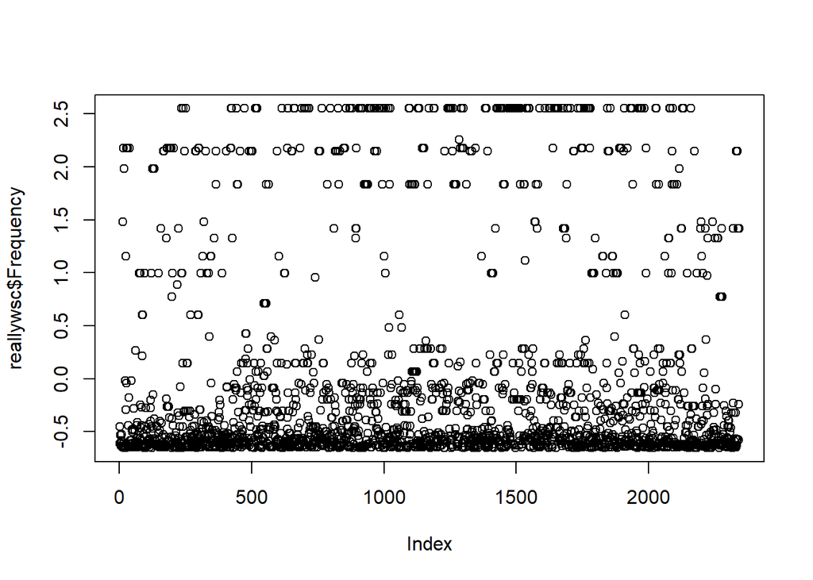

```r
plot(reallywsc$Frequency)
```

We also scale gradability and plot the resulting scaled gradability.

```r
# gradability
reallywsc <- reallywsc %>%
  dplyr::mutate(Gradability  = scale(Gradability-1)) %>%
  dplyr::mutate(Gradability = as.vector(Gradability))
# summarize gradability
summary(reallywsc$Gradability)
```

```
##     Min.  1st Qu.   Median     Mean  3rd Qu.     Max.
## -1.34662 -1.13581  0.09892  0.00000  0.97292  2.71932
```

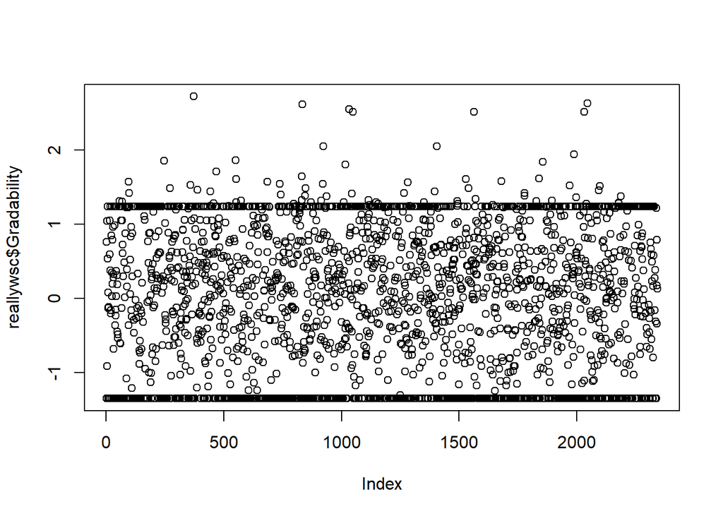

```r
# visualize gradability
plot(reallywsc$Gradability)
```

# 2 CIT

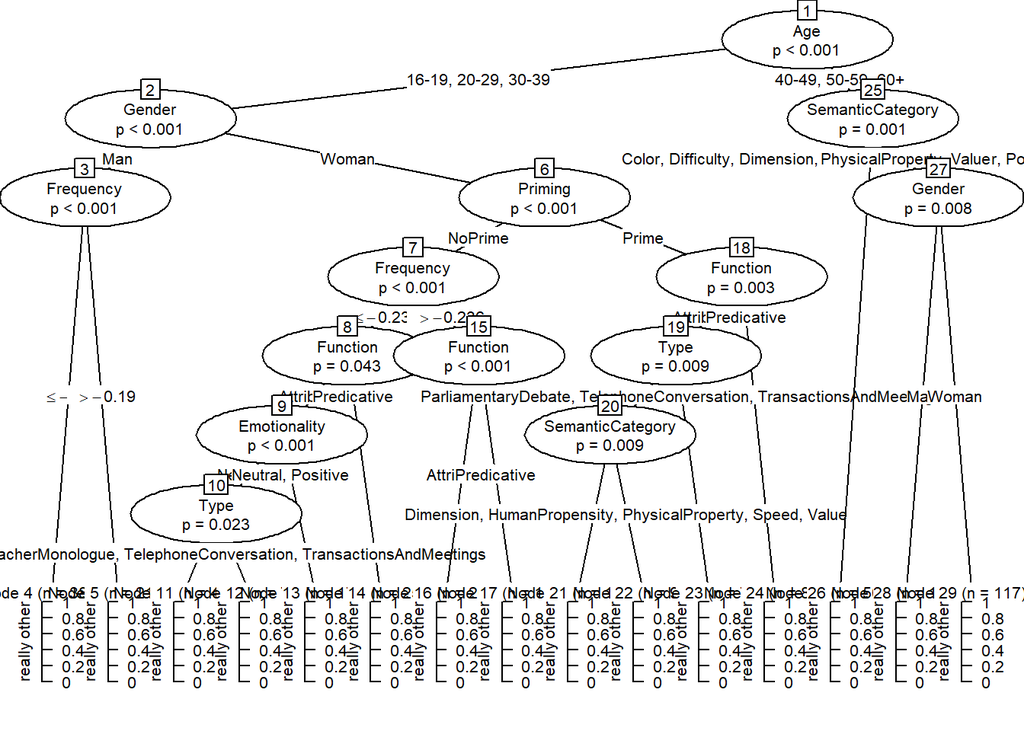

```r
# load packages
library(partykit)
library(tidyverse)
# create data
citdata <- reallywsc
# set seed
set.seed(111)
# apply bonferroni correction (1 minus alpha multiplied by n of predictors)
control = ctree_control(mincriterion = 1-(.05*ncol(citdata)-1))
# create initial conditional inference tree model
citd.ctree <- partykit::ctree(really ~ Age +  SemanticCategory + Frequency +  Priming +
                                Type + Emotionality  + Gender + L1 + Function, data = citdata)
plot(citd.ctree, gp = gpar(fontsize = 8)) # plot final ctree
```

```r
citd.ctree
```

```
##
## Model formula:
## really ~ Age + SemanticCategory + Frequency + Priming + Type +
##     Emotionality + Gender + L1 + Function
##
## Fitted party:
## [1] root
## |   [2] Age in 16-19, 20-29, 30-39
## |   |   [3] Gender in Man
## |   |   |   [4] Frequency <= -0.19029: other (n = 387, err = 22.7%)
## |   |   |   [5] Frequency > -0.19029: other (n = 211, err = 45.5%)
## |   |   [6] Gender in Woman
## |   |   |   [7] Priming in NoPrime
## |   |   |   |   [8] Frequency <= -0.23633
## |   |   |   |   |   [9] Function in Attributive
## |   |   |   |   |   |   [10] Emotionality in Negative
## |   |   |   |   |   |   |   [11] Type in Conversation, Lecture: really (n = 46, err = 17.4%)
## |   |   |   |   |   |   |   [12] Type in TeacherMonologue, TelephoneConversation, TransactionsAndMeetings: other (n = 7, err = 14.3%)
## |   |   |   |   |   |   [13] Emotionality in Neutral, Positive: other (n = 175, err = 39.4%)
## |   |   |   |   |   [14] Function in Predicative: other (n = 259, err = 35.1%)
## |   |   |   |   [15] Frequency > -0.23633
## |   |   |   |   |   [16] Function in Attributive: really (n = 206, err = 26.7%)
## |   |   |   |   |   [17] Function in Predicative: really (n = 112, err = 48.2%)
## |   |   |   [18] Priming in Prime
## |   |   |   |   [19] Function in Attributive
## |   |   |   |   |   [20] Type in Conversation, Lecture
## |   |   |   |   |   |   [21] SemanticCategory in Color, Difficulty, Other: other (n = 10, err = 50.0%)
## |   |   |   |   |   |   [22] SemanticCategory in Dimension, HumanPropensity, PhysicalProperty, Speed, Value: really (n = 99, err = 6.1%)
## |   |   |   |   |   [23] Type in ParliamentaryDebate, TelephoneConversation, TransactionsAndMeetings: other (n = 7, err = 42.9%)
## |   |   |   |   [24] Function in Predicative: really (n = 89, err = 33.7%)
## |   [25] Age in 40-49, 50-59, 60+
## |   |   [26] SemanticCategory in Color, Difficulty, Dimension, HumanPropensity, Other, Position, Speed: other (n = 506, err = 9.3%)
## |   |   [27] SemanticCategory in PhysicalProperty, Value
## |   |   |   [28] Gender in Man: other (n = 113, err = 13.3%)
## |   |   |   [29] Gender in Woman: other (n = 117, err = 31.6%)
##
## Number of inner nodes:    14
## Number of terminal nodes: 15
```

According to the CIT, we can simplify Semantic Category, Type, and Age. However, we will only collapse categories that are conceptually related (collapse Speed, Position, and Dimension as well as Physical Property and Color)

```r
reallywsc <- reallywsc %>%
  # simplify age
  dplyr::mutate(Age = as.character(Age)) %>%
  dplyr::mutate(Age = dplyr::case_when(Age == "16-19" ~ "16-29",
                                       Age == "20-29" ~ "16-29",
                                       Age == "40-49" ~ "40+",
                                       Age == "50-59" ~ "40+",
                                       Age == "60+" ~ "40+",
                                       TRUE ~ Age)) %>%
  # simplify type
  dplyr::mutate(Type = as.character(Type)) %>%
  dplyr::mutate(Type = dplyr::case_when(Type == "Conversation" ~ "Private",
                                        Type == "TelephoneConversation" ~ "Private",
                                        Type == "BroadcastInterview" ~ "Public",
                                        Type == "Lecture" ~ "Public",
                                        Type == "OralHistoryInterview" ~ "Public",
                                        Type == "ParliamentaryDebate" ~ "Public",
                                        Type == "RadioTalkback" ~ "Public",
                                        Type == "SportsCommentary" ~ "Public",
                                        Type == "BroadcastNews" ~ "Formal",
                                        Type == "SocialDialectInterview" ~ "Formal",
                                        Type == "TeacherMonologue" ~ "Formal",
                                        Type == "TransactionsAndMeetings" ~ "Formal",
                                        Type == "BroadcastMonologue" ~ "Formal",
                                        Type == "BroadcastWeather" ~ "Formal",
                                        TRUE ~ Type)) %>%
  # simplify semantic category
  dplyr::mutate(SemanticCategory = as.character(SemanticCategory)) %>%
  dplyr::mutate(SemanticCategory = dplyr::case_when(SemanticCategory == "Speed" ~ "Dimension",
                                                    SemanticCategory == "Position" ~ "Dimension",
                                                    SemanticCategory == "Color" ~ "PhyProperty",
                                                    SemanticCategory == "PhysicalProperty" ~ "PhyProperty",
                                                    SemanticCategory == "HumanPropensity" ~ "Human",
                                                    TRUE ~ SemanticCategory)) %>%
  # simplify Ethnicity
    dplyr::mutate(Ethnicity = as.character(Ethnicity)) %>%
  dplyr::mutate(Ethnicity = dplyr::case_when(Ethnicity == "Maori/Pakeha" ~ "Other",
                                             TRUE ~ Ethnicity)) %>%
  # round Frequency
  dplyr::mutate(Frequency = round(Frequency, 5)) %>%
  # round Gradability
  dplyr::mutate(Gradability = round(Gradability, 5)) %>%
  # factorize
  dplyr::mutate(Age = factor(Age),
                Type = factor(Type),
                SemanticCategory = factor(SemanticCategory),
                Ethnicity = factor(Ethnicity))
# inspect
table(reallywsc$SemanticCategory)
```

```
##
##  Difficulty   Dimension       Human       Other PhyProperty       Value
##         179         191         798         241         173         762
```

```r
table(reallywsc$Age)
```

```
##
## 16-29 30-39   40+
##  1288   320   736
```

```r
table(reallywsc$Type)
```

```
##
##  Formal Private  Public
##     208    1798     338
```

```r
table(reallywsc$Ethnicity)
```

```
##
##  Maori  Other Pakeha
##    224    298   1822
```

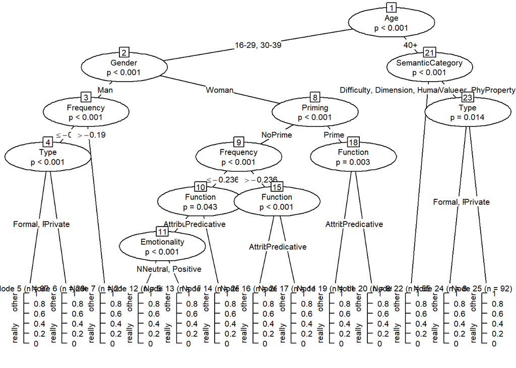

```r
# create data
citdata <- reallywsc
# set seed
set.seed(111)
# apply bonferroni correction (1 minus alpha multiplied by n of predictors)
control = ctree_control(mincriterion = 1-(.05*ncol(citdata)-1))
# create initial conditional inference tree model
citd.ctree <- partykit::ctree(really ~ Age +  SemanticCategory + Frequency +  Priming +
                                Type + Emotionality  + Gender + L1 + Function, data = citdata)
plot(citd.ctree, gp = gpar(fontsize = 8)) # plot final ctree
```

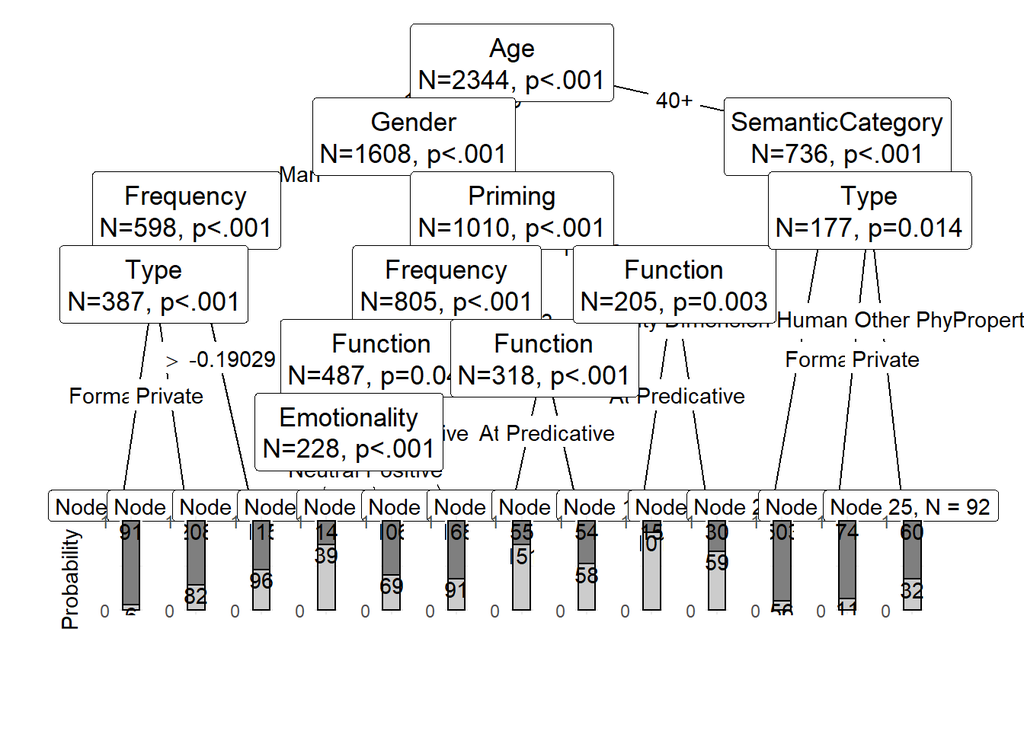

```r
# activate package
library(ggparty)
# extract p-values
pvals <- unlist(nodeapply(citd.ctree, ids = nodeids(citd.ctree), function(n) info_node(n)$p.value))
pvals <- pvals[pvals <.05]
# plotting
ggparty(citd.ctree) +
  geom_edge() +
  geom_edge_label() +
  geom_node_label(line_list = list(aes(label = splitvar),
                                   aes(label = paste0("N=", nodesize, ", p",
                                                      ifelse(pvals < .001, "<.001", paste0("=", round(pvals, 3)))),
                                       size = 13)),
                  line_gpar = list(list(size = 13),
                                   list(size = 13)),
                  ids = "inner") +
  geom_node_label(aes(label = paste0("Node ", id, ", N = ", nodesize)),
    ids = "terminal", nudge_y = -0.0, nudge_x = 0.01) +
  geom_node_plot(gglist = list(
    geom_bar(aes(x = "", fill = really),
             position = position_fill(), color = "black"),
      theme_minimal(),
      scale_fill_manual(values = c("gray50", "gray80"), guide = FALSE),
      scale_y_continuous(breaks = c(0, 1)),
    xlab(""),
    ylab("Probability"),
    geom_text(aes(x = "", group = really,
                  label = stat(count)),
              stat = "count", position = position_fill(), vjust = 1.1)),
    shared_axis_labels = TRUE) +
  ggsave(file =  here::here("images", "Cit_really.png"),
         width = 60, height = 30, units = c("cm"),  dpi = 600)
```

# 3 Boruta

We now begin with the modeling. In a first step, we use a Boruta analysis as a variable selection procedure to determine which variables have any sort of meaningful relationship with the dependent variable. We will only consider variables which have been deemed as being important during the model fitting process.

```r
# load library
library(Boruta)
# create data for boruta
borutadata <- reallywsc %>%
  na.omit()
# save and load data
write.table(borutadata, here::here("data", "borutadata.txt"), sep = "\t",
            col.names = T, row.names = F, quote = F)
# run 1
set.seed(2019121201)
boruta1 <- Boruta(really ~.,data=borutadata)
print(boruta1)
```

```
## Boruta performed 99 iterations in 1.012804 mins.
##  11 attributes confirmed important: Adjective, Age, Emotionality,
## Ethnicity, Frequency and 6 more;
##  No attributes deemed unimportant.
##  2 tentative attributes left: Education, L1;
```

We now begin with the modelling. In a first step, we use a Boruta analysis as a variable selection procedure to determine which variables have any sort of meaningful relationship with the dependent variable.

```r
rejected <- names(boruta1$finalDecision)[which(boruta1$finalDecision == "Rejected")]
# update data for boruta
borutadata <- borutadata %>%
  dplyr::select(-rejected)
# run 2
set.seed(2019121202)
boruta2 <- Boruta(really ~.,data=borutadata)
print(boruta2)
```

```
## Boruta performed 99 iterations in 1.039042 mins.
##  11 attributes confirmed important: Adjective, Age, Emotionality,
## Ethnicity, Frequency and 6 more;
##  No attributes deemed unimportant.
##  2 tentative attributes left: Education, L1;
```

```r
rejected <- names(boruta1$finalDecision)[which(boruta1$finalDecision == "Tentative")]
# update data for boruta
borutadata <- borutadata %>%
  dplyr::select(-rejected)
# run 3
set.seed(2019121203)
boruta3 <- Boruta(really ~., data=borutadata)
print(boruta3)
```

```
## Boruta performed 11 iterations in 6.246924 secs.
##  11 attributes confirmed important: Adjective, Age, Emotionality,
## Ethnicity, Frequency and 6 more;
##  No attributes deemed unimportant.
```

No more variables need to be removed. We now inspect the visualizations of the Boruta analysis.

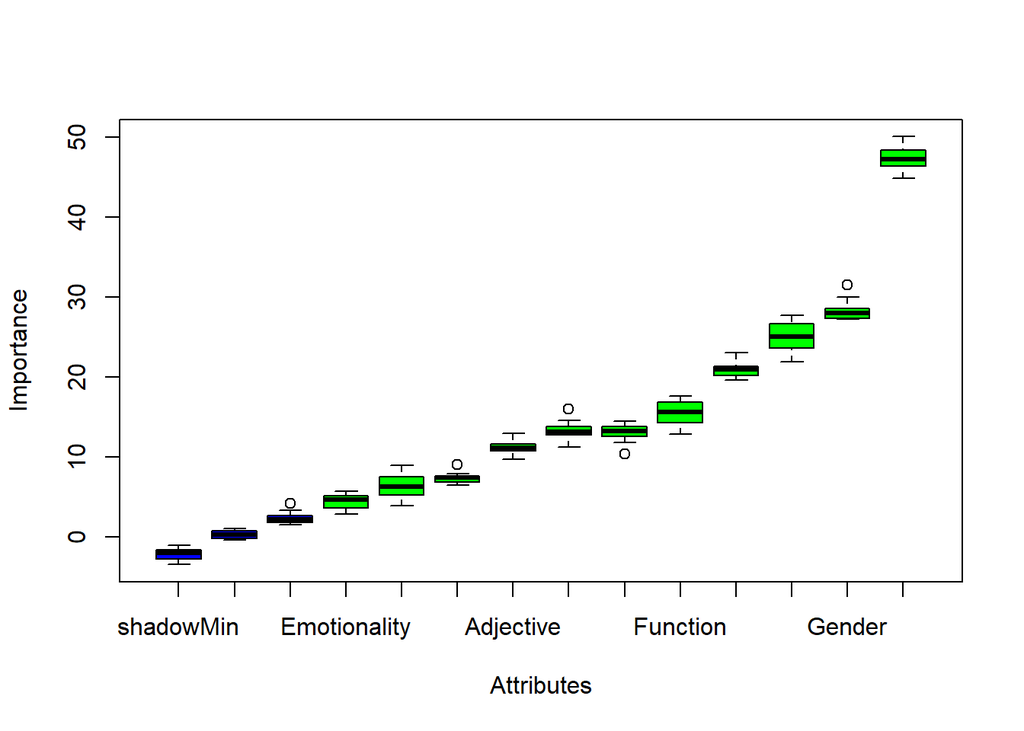

```r
plot(boruta3)
```

In addition, we inspect the history of the Boruta runs.

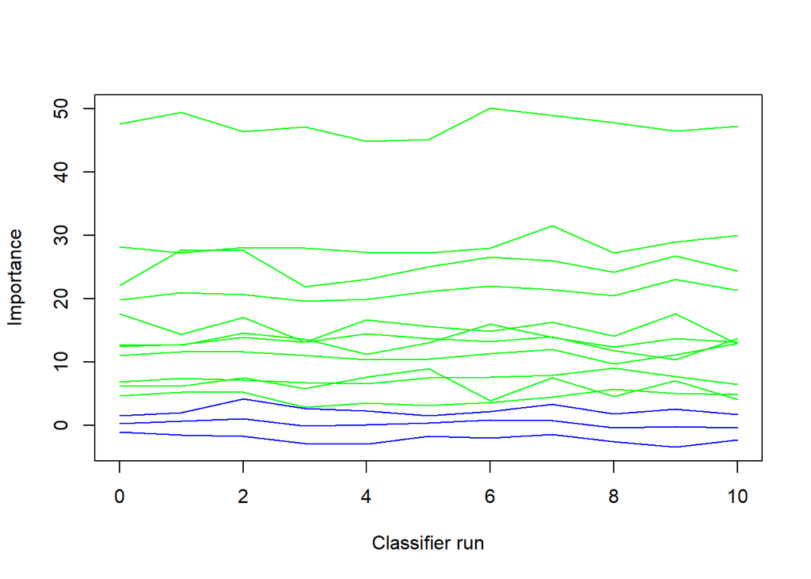

```r
plotImpHistory(boruta3)
```

Now, we create the final publication visualization of the Boruta analysis.

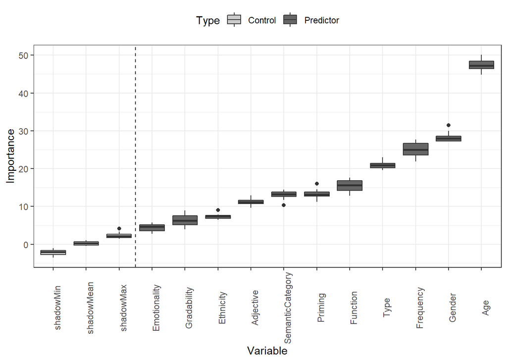

```r
borutadf <- as.data.frame(boruta3$ImpHistory) %>%
  gather(Variable, Importance, Adjective:shadowMin) %>%
  mutate(Type = ifelse(str_detect(Variable, "shadow"), "Control", "Predictor")) %>%
  mutate(Type = factor(Type),
         Variable = factor(Variable))
ggplot(borutadf, aes(x = reorder(Variable, Importance, mean), y = Importance, fill = Type)) +
  geom_boxplot() +
  geom_vline(xintercept=3.5, linetype="dashed", color = "black") +
  scale_fill_manual(values = c("gray80", "gray40")) +
  theme_bw() +
  theme(legend.position = "top",
        axis.text.x = element_text(angle=90)) +
  labs(x = "Variable") +
  ggsave(file =  here::here("images", "Boruta_really.png"),
         width = 15, height = 10, units = c("cm"),  dpi = 600)
```

# 4 Mixed-Effects Model

We begin with the model fitting by setting options and creating intercept-only base-line models.

```r
# load library
library(rms)
# set options
options(contrasts  =c("contr.treatment", "contr.poly"))
reallywsc.dist <- datadist(reallywsc)
options(datadist = "reallywsc.dist")
# generate initial minimal regression model
m0.glm = glm(really ~ 1, family = binomial, data = reallywsc)
# inspect results
summary(m0.glm)
```

```
##
## Call:
## glm(formula = really ~ 1, family = binomial, data = reallywsc)
##
## Deviance Residuals:
##     Min       1Q   Median       3Q      Max
## -0.9498  -0.9498  -0.9498   1.4235   1.4235
##
## Coefficients:
##             Estimate Std. Error z value            Pr(>|z|)
## (Intercept) -0.56213    0.04295  -13.09 <0.0000000000000002 ***
## ---
## Signif. codes:  0 '***' 0.001 '**' 0.01 '*' 0.05 '.' 0.1 ' ' 1
##
## (Dispersion parameter for binomial family taken to be 1)
##
##     Null deviance: 3071.4  on 2343  degrees of freedom
## Residual deviance: 3071.4  on 2343  degrees of freedom
## AIC: 3073.4
##
## Number of Fisher Scoring iterations: 4
```

In a next step, we create analogous base-line models with Adjective as a random effect (random intercepts).

```r
# load packages
library(lme4)
library(car)
# create model with a random intercept for Adjective
m0.glmer = glmer(really ~ (1|Adjective), data = reallywsc, family = binomial)
```

We can now use the AIC to determine if including a random effect structure is justified.

```r
aic.glmer <- AIC(logLik(m0.glmer))
aic.glm <- AIC(logLik(m0.glm))
aic.glmer; aic.glm
```

```
## [1] 2861.337
```

```
## [1] 3073.369
```

The AIC of the glmer object is substantially smaller which indicates that including the random intercepts appears to be justified.

## Model fitting

#### Age

```r
#   manual modelfitting
m0.glmer <- glmer(really ~ 1 + (1|Adjective), family = binomial, data = reallywsc,
                  control=glmerControl(optimizer="bobyqa"))
# add Age
ifelse(min(ftable(reallywsc$Age, reallywsc$really)) == 0, "not possible", "possible")
```

```
## [1] "possible"
```

```r
m1.glmer <- update(m0.glmer, .~.+Age)
anova(m0.glmer, m1.glmer, test = "Chi")
```

```
## Data: reallywsc
## Models:
## m0.glmer: really ~ 1 + (1 | Adjective)
## m1.glmer: really ~ (1 | Adjective) + Age
##          npar    AIC    BIC  logLik deviance  Chisq Df            Pr(>Chisq)
## m0.glmer    2 2861.3 2872.9 -1428.7   2857.3
## m1.glmer    4 2653.7 2676.7 -1322.8   2645.7 211.69  2 < 0.00000000000000022
##
## m0.glmer
## m1.glmer ***
## ---
## Signif. codes:  0 '***' 0.001 '**' 0.01 '*' 0.05 '.' 0.1 ' ' 1
```

```r
Anova(m1.glmer, type = "III", test = "Chi")
```

```
## Analysis of Deviance Table (Type III Wald chisquare tests)
##
## Response: really
##               Chisq Df            Pr(>Chisq)
## (Intercept)  31.819  1         0.00000001692 ***
## Age         184.462  2 < 0.00000000000000022 ***
## ---
## Signif. codes:  0 '***' 0.001 '**' 0.01 '*' 0.05 '.' 0.1 ' ' 1
```

Probability of really among speakers aged 40+

```r
round(plogis(fixef(m1.glmer)[1] + fixef(m1.glmer)[3])*100, 2)
```

```
## (Intercept)
##        8.56
```

We will now check if the sample size is sufficient to detect a medium-sized effect (Cohen’s d 0.5) - the traditional scale is 0.2 for a small, 0.5 for medium-sized, and 0.8 for a large or strong effect.

In order to check what a medium-sized effect is, we need to determine the odds ratios of the fixed effects and then convert them into Cohen’s d values for which we have associations between traditional denominations (small, medium, and large) and effect sife values. According to Chen, Cohen, and Chen (2010) odds ratios of 1.68, 3.47, and 6.71 are equivalent to Cohen’s d = 0.2 (small), 0.5 (medium), and 0.8 (large).

```r
pm1 <- m1.glmer
estimatesfixedeffects <- fixef(pm1)
exp(estimatesfixedeffects)
```

```
## (Intercept)    Age30-39      Age40+
##   0.5514444   0.5564163   0.1698424
```

```r
fixef(pm1)["Age40+"] <- 1.244
estimatesfixedeffects <- fixef(pm1)
exp(estimatesfixedeffects)
simr::powerSim(pm1, fixed("Age", "lr"), nsim=100)
```

#### Frequency

```r
# add Frequency
m2.glmer <- update(m1.glmer, .~.+ Frequency)
car::vif(m2.glmer)
```

```
##               GVIF Df GVIF^(1/(2*Df))
## Age       1.138506  2        1.032961
## Frequency 1.138506  1        1.067008
```

```r
anova(m2.glmer, m1.glmer, test = "Chi")
```

```
## Data: reallywsc
## Models:
## m1.glmer: really ~ (1 | Adjective) + Age
## m2.glmer: really ~ (1 | Adjective) + Age + Frequency
##          npar    AIC    BIC  logLik deviance Chisq Df Pr(>Chisq)
## m1.glmer    4 2653.7 2676.7 -1322.8   2645.7
## m2.glmer    5 2654.8 2683.6 -1322.4   2644.8 0.807  1      0.369
```

```r
pm2 <- m2.glmer
fixef(pm2)["Frequency"] <- 1.244
estimatesfixedeffects <- fixef(pm2)
simr::powerSim(pm2, fixed("Frequency", "lr"), nsim=100)
```

#### Priming

```r
ifelse(min(ftable(reallywsc$Priming, reallywsc$really)) == 0, "not possible", "possible")
```

```
## [1] "possible"
```

```r
m3.glmer <- update(m1.glmer, .~.+Priming)
car::vif(m3.glmer)
```

```
##            GVIF Df GVIF^(1/(2*Df))
## Age     1.00303  2        1.000757
## Priming 1.00303  1        1.001514
```

```r
anova(m3.glmer, m1.glmer, test = "Chi")
```

```
## Data: reallywsc
## Models:
## m1.glmer: really ~ (1 | Adjective) + Age
## m3.glmer: really ~ (1 | Adjective) + Age + Priming
##          npar    AIC    BIC  logLik deviance  Chisq Df   Pr(>Chisq)
## m1.glmer    4 2653.7 2676.7 -1322.8   2645.7
## m3.glmer    5 2629.6 2658.3 -1309.8   2619.6 26.098  1 0.0000003245 ***
## ---
## Signif. codes:  0 '***' 0.001 '**' 0.01 '*' 0.05 '.' 0.1 ' ' 1
```

```r
Anova(m3.glmer, type = "III", test = "Chi")
```

```
## Analysis of Deviance Table (Type III Wald chisquare tests)
##
## Response: really
##               Chisq Df            Pr(>Chisq)
## (Intercept)  43.194  1      0.00000000004956 ***
## Age         174.444  2 < 0.00000000000000022 ***
## Priming      25.976  1      0.00000034577767 ***
## ---
## Signif. codes:  0 '***' 0.001 '**' 0.01 '*' 0.05 '.' 0.1 ' ' 1
```

```r
pm3 <- m3.glmer
fixef(pm3)["PrimingPrime"] <- 1.244
estimatesfixedeffects <- fixef(pm3)
pm3_results <- simr::powerSim(pm3, fixed("PrimingPrime", "z"), nsim=100)
pm3_results
```

#### Emotionality

```r
ifelse(min(ftable(reallywsc$Emotionality, reallywsc$really)) == 0, "not possible", "possible")
```

```
## [1] "possible"
```

```r
m4.glmer <- update(m3.glmer, .~.+Emotionality)
car::vif(m4.glmer)
```

```
##                  GVIF Df GVIF^(1/(2*Df))
## Age          1.005779  2        1.001442
## Priming      1.003302  1        1.001650
## Emotionality 1.003076  2        1.000768
```

```r
anova(m4.glmer, m3.glmer, test = "Chi")
```

```
## Data: reallywsc
## Models:
## m3.glmer: really ~ (1 | Adjective) + Age + Priming
## m4.glmer: really ~ (1 | Adjective) + Age + Priming + Emotionality
##          npar    AIC    BIC  logLik deviance  Chisq Df Pr(>Chisq)
## m3.glmer    5 2629.6 2658.3 -1309.8   2619.6
## m4.glmer    7 2628.1 2668.4 -1307.0   2614.1 5.4776  2    0.06465 .
## ---
## Signif. codes:  0 '***' 0.001 '**' 0.01 '*' 0.05 '.' 0.1 ' ' 1
```

```r
Anova(m4.glmer, type = "III", test = "Chi")
```

```
## Analysis of Deviance Table (Type III Wald chisquare tests)
##
## Response: really
##                 Chisq Df            Pr(>Chisq)
## (Intercept)    5.2611  1               0.02181 *
## Age          171.0595  2 < 0.00000000000000022 ***
## Priming       26.2056  1          0.0000003069 ***
## Emotionality   5.3653  2               0.06838 .
## ---
## Signif. codes:  0 '***' 0.001 '**' 0.01 '*' 0.05 '.' 0.1 ' ' 1
```

```r
pm4 <- m4.glmer
fixef(pm4)["EmotionalityPositive"] <- 1.244 # positive because it has fewer observations
estimatesfixedeffects <- fixef(pm4)
pm3_results <- simr::powerSim(pm4, fixed("EmotionalityPositive", "z"), nsim=100)
pm3_results
```

#### Type

```r
ifelse(min(ftable(reallywsc$Type, reallywsc$really)) == 0, "not possible", "possible")
```

```
## [1] "possible"
```

```r
m5.glmer <- update(m3.glmer, .~.+Type)
car::vif(m5.glmer)
```

```
##             GVIF Df GVIF^(1/(2*Df))
## Age     1.074761  2        1.018188
## Priming 1.005092  1        1.002543
## Type    1.072834  2        1.017731
```

```r
anova(m5.glmer, m3.glmer, test = "Chi")
```

```
## Data: reallywsc
## Models:
## m3.glmer: really ~ (1 | Adjective) + Age + Priming
## m5.glmer: really ~ (1 | Adjective) + Age + Priming + Type
##          npar    AIC    BIC  logLik deviance  Chisq Df       Pr(>Chisq)
## m3.glmer    5 2629.6 2658.3 -1309.8   2619.6
## m5.glmer    7 2584.3 2624.6 -1285.1   2570.3 49.288  2 0.00000000001983 ***
## ---
## Signif. codes:  0 '***' 0.001 '**' 0.01 '*' 0.05 '.' 0.1 ' ' 1
```

```r
Anova(m5.glmer, type = "III", test = "Chi")
```

```
## Analysis of Deviance Table (Type III Wald chisquare tests)
##
## Response: really
##               Chisq Df            Pr(>Chisq)
## (Intercept)  35.607  1       0.0000000024141 ***
## Age         117.251  2 < 0.00000000000000022 ***
## Priming      27.006  1       0.0000002027759 ***
## Type         45.141  2       0.0000000001577 ***
## ---
## Signif. codes:  0 '***' 0.001 '**' 0.01 '*' 0.05 '.' 0.1 ' ' 1
```

```r
pm5 <- m5.glmer
fixef(pm5)["TypePublicConversation"] <- 1.244 # PublicConversation because it has fewer observations
estimatesfixedeffects <- fixef(pm5)
pm5_results <- simr::powerSim(pm5, fixed("TypePublicConversation", "z"), nsim=100)
pm5_results
```

#### Gender

```r
ifelse(min(ftable(reallywsc$Gender, reallywsc$really)) == 0, "not possible", "possible")
```

```
## [1] "possible"
```

```r
m6.glmer <- update(m5.glmer, .~.+Gender)
car::vif(m6.glmer)
```

```
##             GVIF Df GVIF^(1/(2*Df))
## Age     1.097168  2        1.023454
## Priming 1.005069  1        1.002532
## Type    1.113380  2        1.027214
## Gender  1.042389  1        1.020974
```

```r
anova(m6.glmer, m5.glmer, test = "Chi")
```

```
## Data: reallywsc
## Models:
## m5.glmer: really ~ (1 | Adjective) + Age + Priming + Type
## m6.glmer: really ~ (1 | Adjective) + Age + Priming + Type + Gender
##          npar    AIC    BIC  logLik deviance Chisq Df            Pr(>Chisq)
## m5.glmer    7 2584.3 2624.6 -1285.1   2570.3
## m6.glmer    8 2506.2 2552.3 -1245.1   2490.2 80.01  1 < 0.00000000000000022 ***
## ---
## Signif. codes:  0 '***' 0.001 '**' 0.01 '*' 0.05 '.' 0.1 ' ' 1
```

```r
Anova(m6.glmer, type = "III", test = "Chi")
```

```
## Analysis of Deviance Table (Type III Wald chisquare tests)
##
## Response: really
##               Chisq Df            Pr(>Chisq)
## (Intercept)  62.191  1  0.000000000000003118 ***
## Age         124.647  2 < 0.00000000000000022 ***
## Priming      24.499  1  0.000000743446619524 ***
## Type         24.364  2  0.000005121764640659 ***
## Gender       76.301  1 < 0.00000000000000022 ***
## ---
## Signif. codes:  0 '***' 0.001 '**' 0.01 '*' 0.05 '.' 0.1 ' ' 1
```

```r
pm6 <- m6.glmer
fixef(pm6)["GenderWoman"] <- 1.244
estimatesfixedeffects <- fixef(pm6)
pm6_results <- simr::powerSim(pm6, fixed("GenderWoman", "z"), nsim=100)
pm6_results
```

#### Semantic Category

```r
m7.glmer <- update(m6.glmer, .~.+ SemanticCategory)
car::vif(m7.glmer)
```

```
##                      GVIF Df GVIF^(1/(2*Df))
## Age              1.106632  2        1.025654
## Priming          1.007874  1        1.003929
## Type             1.120242  2        1.028793
## Gender           1.047010  1        1.023235
## SemanticCategory 1.022120  5        1.002190
```

```r
anova(m7.glmer, m6.glmer, test = "Chi")
```

```
## Data: reallywsc
## Models:
## m6.glmer: really ~ (1 | Adjective) + Age + Priming + Type + Gender
## m7.glmer: really ~ (1 | Adjective) + Age + Priming + Type + Gender + SemanticCategory
##          npar    AIC    BIC  logLik deviance  Chisq Df Pr(>Chisq)
## m6.glmer    8 2506.2 2552.3 -1245.1   2490.2
## m7.glmer   13 2504.2 2579.1 -1239.1   2478.2 12.027  5    0.03443 *
## ---
## Signif. codes:  0 '***' 0.001 '**' 0.01 '*' 0.05 '.' 0.1 ' ' 1
```

```r
Anova(m7.glmer, type = "III", test = "Chi")
```

```
## Analysis of Deviance Table (Type III Wald chisquare tests)
##
## Response: really
##                    Chisq Df            Pr(>Chisq)
## (Intercept)       14.808  1              0.000119 ***
## Age              121.212  2 < 0.00000000000000022 ***
## Priming           25.323  1          0.0000004848 ***
## Type              23.049  2          0.0000098846 ***
## Gender            76.403  1 < 0.00000000000000022 ***
## SemanticCategory  11.679  5              0.039456 *
## ---
## Signif. codes:  0 '***' 0.001 '**' 0.01 '*' 0.05 '.' 0.1 ' ' 1
```

```r
pm7 <- m7.glmer
fixef(pm7)["SemanticCategoryPhysicalProperty"] <- 1.244 # PhysicalProperty because it has fewer observations
estimatesfixedeffects <- fixef(pm7)
pm7_results <- simr::powerSim(pm7, fixed("SemanticCategoryPhysicalProperty", "z"), nsim=100)
pm7_results
```

#### Ethnicity

```r
ifelse(min(ftable(reallywsc$Ethnicity, reallywsc$really)) == 0, "not possible", "possible")
```

```
## [1] "possible"
```

```r
m8.glmer <- update(m7.glmer, .~.+Ethnicity)
car::vif(m8.glmer)
```

```
##                      GVIF Df GVIF^(1/(2*Df))
## Age              1.140867  2        1.033496
## Priming          1.008920  1        1.004450
## Type             1.138814  2        1.033031
## Gender           1.048457  1        1.023942
## SemanticCategory 1.026191  5        1.002589
## Ethnicity        1.055647  2        1.013630
```

```r
anova(m8.glmer, m7.glmer, test = "Chi")
```

```
## Data: reallywsc
## Models:
## m7.glmer: really ~ (1 | Adjective) + Age + Priming + Type + Gender + SemanticCategory
## m8.glmer: really ~ (1 | Adjective) + Age + Priming + Type + Gender + SemanticCategory +
## m8.glmer:     Ethnicity
##          npar    AIC    BIC  logLik deviance  Chisq Df Pr(>Chisq)
## m7.glmer   13 2504.2 2579.1 -1239.1   2478.2
## m8.glmer   15 2505.9 2592.3 -1238.0   2475.9 2.3117  2     0.3148
```

#### Education

```r
ifelse(min(ftable(reallywsc$Education, reallywsc$really)) == 0, "not possible", "possible")
```

```
## [1] "possible"
```

```r
m9.glmer <- update(m7.glmer, .~.+Education)
car::vif(m9.glmer)
```

```
##                      GVIF Df GVIF^(1/(2*Df))
## Age              1.134999  2        1.032164
## Priming          1.008411  1        1.004197
## Type             1.120716  2        1.028902
## Gender           1.047270  1        1.023362
## SemanticCategory 1.022533  5        1.002231
## Education        1.029546  1        1.014665
```

```r
anova(m9.glmer, m7.glmer, test = "Chi")
```

```
## Data: reallywsc
## Models:
## m7.glmer: really ~ (1 | Adjective) + Age + Priming + Type + Gender + SemanticCategory
## m9.glmer: really ~ (1 | Adjective) + Age + Priming + Type + Gender + SemanticCategory +
## m9.glmer:     Education
##          npar    AIC    BIC  logLik deviance  Chisq Df Pr(>Chisq)
## m7.glmer   13 2504.2 2579.1 -1239.1   2478.2
## m9.glmer   14 2506.2 2586.8 -1239.1   2478.2 0.0285  1     0.8659
```

```r
Anova(m9.glmer, type = "III", test = "Chi")
```

```
## Analysis of Deviance Table (Type III Wald chisquare tests)
##
## Response: really
##                     Chisq Df            Pr(>Chisq)
## (Intercept)       14.4143  1             0.0001467 ***
## Age              117.7377  2 < 0.00000000000000022 ***
## Priming           25.2783  1          0.0000004963 ***
## Type              23.0642  2          0.0000098101 ***
## Gender            76.4104  1 < 0.00000000000000022 ***
## SemanticCategory  11.6957  5             0.0392038 *
## Education          0.0286  1             0.8655930
## ---
## Signif. codes:  0 '***' 0.001 '**' 0.01 '*' 0.05 '.' 0.1 ' ' 1
```

```r
pm9 <- m9.glmer
fixef(pm9)["EducationUniversity"] <- 1.244
estimatesfixedeffects <- fixef(pm9)
pm9_results <- simr::powerSim(pm9, fixed("EducationUniversity", "z"), nsim=100)
pm9_results
```

#### Gradability

```r
m10.glmer <- update(m7.glmer, .~.+Gradability)
car::vif(m10.glmer)
```

```
##                      GVIF Df GVIF^(1/(2*Df))
## Age              1.107324  2        1.025814
## Priming          1.008037  1        1.004011
## Type             1.120474  2        1.028846
## Gender           1.047540  1        1.023494
## SemanticCategory 1.029131  5        1.002876
## Gradability      1.007402  1        1.003694
```

```r
anova(m10.glmer, m7.glmer, test = "Chi")
```

```
## Data: reallywsc
## Models:
## m7.glmer: really ~ (1 | Adjective) + Age + Priming + Type + Gender + SemanticCategory
## m10.glmer: really ~ (1 | Adjective) + Age + Priming + Type + Gender + SemanticCategory +
## m10.glmer:     Gradability
##           npar    AIC    BIC  logLik deviance  Chisq Df Pr(>Chisq)
## m7.glmer    13 2504.2 2579.1 -1239.1   2478.2
## m10.glmer   14 2502.9 2583.5 -1237.4   2474.9 3.3608  1    0.06677 .
## ---
## Signif. codes:  0 '***' 0.001 '**' 0.01 '*' 0.05 '.' 0.1 ' ' 1
```

```r
Anova(m10.glmer, type = "III", test = "Chi")
```

```
## Analysis of Deviance Table (Type III Wald chisquare tests)
##
## Response: really
##                     Chisq Df            Pr(>Chisq)
## (Intercept)       15.2126  1          0.0000960594 ***
## Age              120.9375  2 < 0.00000000000000022 ***
## Priming           25.4335  1          0.0000004579 ***
## Type              22.8751  2          0.0000107827 ***
## Gender            76.2997  1 < 0.00000000000000022 ***
## SemanticCategory  11.6964  5               0.03919 *
## Gradability        3.3751  1               0.06619 .
## ---
## Signif. codes:  0 '***' 0.001 '**' 0.01 '*' 0.05 '.' 0.1 ' ' 1
```

```r
pm10 <- m10.glmer
fixef(pm10)["Gradability"] <- 1.244
estimatesfixedeffects <- fixef(pm10)
pm10_results <- simr::powerSim(pm10, fixed("Gradability", "z"), nsim=100)
pm10_results
```

## Interactions

```r
# find all 2-way interactions
library(utils)
#colnames(reallywsc) # remove # to activate
vars <- c("Age",  "SemanticCategory", "Frequency", "Priming",
          "Emotionality", "Type", "Gender", "Ethnicity", "Education",
          "Gradability")
intac <- t(combn(vars, 2))
intac
```

```
##       [,1]               [,2]
##  [1,] "Age"              "SemanticCategory"
##  [2,] "Age"              "Frequency"
##  [3,] "Age"              "Priming"
##  [4,] "Age"              "Emotionality"
##  [5,] "Age"              "Type"
##  [6,] "Age"              "Gender"
##  [7,] "Age"              "Ethnicity"
##  [8,] "Age"              "Education"
##  [9,] "Age"              "Gradability"
## [10,] "SemanticCategory" "Frequency"
## [11,] "SemanticCategory" "Priming"
## [12,] "SemanticCategory" "Emotionality"
## [13,] "SemanticCategory" "Type"
## [14,] "SemanticCategory" "Gender"
```

[output cut: 31 more lines]

#### 4.0.0.1 Check interactions

```r
ifelse(min(ftable(reallywsc$Age, reallywsc$SemanticCategory, reallywsc$really)) == 0, "not possible", "possible")
```

```
## [1] "possible"
```

```r
m12.glmer <-  update(m7.glmer, .~.+ Age * SemanticCategory)
max(car::vif(m12.glmer)[,1])
```

```
## [1] 604.1995
```

```r
# excessive vifs
```

```r
m13.glmer <-  update(m7.glmer, .~.+ Age * Frequency)
max(car::vif(m13.glmer)[,1])
```

```
## [1] 1.347225
```

```r
anova(m13.glmer, m7.glmer, test = "Chi")
```

```
## Data: reallywsc
## Models:
## m7.glmer: really ~ (1 | Adjective) + Age + Priming + Type + Gender + SemanticCategory
## m13.glmer: really ~ (1 | Adjective) + Age + Priming + Type + Gender + SemanticCategory +
## m13.glmer:     Frequency + Age:Frequency
##           npar    AIC    BIC  logLik deviance  Chisq Df Pr(>Chisq)
## m7.glmer    13 2504.2 2579.1 -1239.1   2478.2
## m13.glmer   16 2507.0 2599.2 -1237.5   2475.0 3.1856  3     0.3639
```

```r
pm13 <- m13.glmer
fixef(pm13)["Age40+:Frequency"] <- 1.244
estimatesfixedeffects <- fixef(pm13)
pm13_results <- simr::powerSim(pm13, fixed("Age40+:Frequency", "z"), nsim=100)
pm13_results
```

```r
ifelse(min(ftable(reallywsc$Age, reallywsc$Priming, reallywsc$really)) == 0, "not possible", "possible")
```

```
## [1] "possible"
```

```r
m14.glmer <-  update(m7.glmer, .~.+ Age * Priming)
max(car::vif(m14.glmer)[,1])
```

```
## [1] 1.596513
```

```r
anova(m14.glmer, m7.glmer, test = "Chi")
```

```
## Data: reallywsc
## Models:
## m7.glmer: really ~ (1 | Adjective) + Age + Priming + Type + Gender + SemanticCategory
## m14.glmer: really ~ (1 | Adjective) + Age + Priming + Type + Gender + SemanticCategory +
## m14.glmer:     Age:Priming
##           npar    AIC    BIC  logLik deviance  Chisq Df Pr(>Chisq)
## m7.glmer    13 2504.2 2579.1 -1239.1   2478.2
## m14.glmer   15 2487.8 2574.2 -1228.9   2457.8 20.427  2 0.00003668 ***
## ---
## Signif. codes:  0 '***' 0.001 '**' 0.01 '*' 0.05 '.' 0.1 ' ' 1
```

```r
Anova(m14.glmer, type = "III", test = "Chi")
```

```
## Analysis of Deviance Table (Type III Wald chisquare tests)
##
## Response: really
##                   Chisq Df            Pr(>Chisq)
## (Intercept)      15.835  1        0.000069116824 ***
## Age              77.663  2 < 0.00000000000000022 ***
## Priming          37.646  1        0.000000000848 ***
## Type             23.761  2        0.000006925003 ***
## Gender           77.440  1 < 0.00000000000000022 ***
## SemanticCategory 11.206  5             0.0474518 *
## Age:Priming      16.410  2             0.0002733 ***
## ---
## Signif. codes:  0 '***' 0.001 '**' 0.01 '*' 0.05 '.' 0.1 ' ' 1
```

```r
pm14 <- m14.glmer
fixef(pm14)["Age40+:PrimingPrime"] <- 1.244
estimatesfixedeffects <- fixef(pm14)
pm14_results <- simr::powerSim(pm14, fixed("Age40+:PrimingPrime", "z"), nsim=100)
pm14_results
```

```r
ifelse(min(ftable(reallywsc$Age, reallywsc$Emotionality, reallywsc$really)) == 0, "not possible", "possible")
```

```
## [1] "possible"
```

```r
m15.glmer <-  update(m14.glmer, .~.+ Age * Emotionality)
max(car::vif(m15.glmer)[,1])
```

```
## [1] 79.42719
```

```r
# excessive vifs
```

```r
ifelse(min(ftable(reallywsc$Age, reallywsc$Type, reallywsc$really)) == 0, "not possible", "possible")
```

```
## [1] "possible"
```

```r
m16.glmer <-  update(m14.glmer, .~.+ Age * Type)
max(car::vif(m16.glmer)[,1])
```

```
## [1] 375.7473
```

```r
# excessive vifs
```

```r
ifelse(min(ftable(reallywsc$Age, reallywsc$Gender, reallywsc$really)) == 0, "not possible", "possible")
```

```
## [1] "possible"
```

```r
m17.glmer <-  update(m14.glmer, .~.+ Age * Gender)
max(car::vif(m17.glmer)[,1])
```

```
## [1] 10.97095
```

```r
# excessive vifs
```

```r
ifelse(min(ftable(reallywsc$Age, reallywsc$Ethnicity, reallywsc$really)) == 0, "not possible", "possible")
```

```
## [1] "possible"
```

```r
m18.glmer <-  update(m14.glmer, .~.+ Age * Ethnicity)
max(car::vif(m18.glmer)[,1])
```

```
## [1] 92.72127
```

```r
# excessive vifs
```

```r
ifelse(min(ftable(reallywsc$Age, reallywsc$Education, reallywsc$really)) == 0, "not possible", "possible")
```

```
## [1] "possible"
```

```r
m19.glmer <-  update(m14.glmer, .~.+ Age * Education)
max(car::vif(m19.glmer)[,1])
```

```
## [1] 6.789097
```

```r
# excessive vifs
```

```r
m20.glmer <-  update(m14.glmer, .~.+ Age * Gradability)
max(car::vif(m20.glmer)[,1])
```

```
## [1] 1.61241
```

```r
anova(m20.glmer, m14.glmer, test = "Chi")
```

```
## Data: reallywsc
## Models:
## m14.glmer: really ~ (1 | Adjective) + Age + Priming + Type + Gender + SemanticCategory +
## m14.glmer:     Age:Priming
## m20.glmer: really ~ (1 | Adjective) + Age + Priming + Type + Gender + SemanticCategory +
## m20.glmer:     Gradability + Age:Priming + Age:Gradability
##           npar    AIC    BIC  logLik deviance  Chisq Df Pr(>Chisq)
## m14.glmer   15 2487.8 2574.2 -1228.9   2457.8
## m20.glmer   18 2488.6 2592.2 -1226.3   2452.6 5.2346  3     0.1554
```

```r
pm20 <- m20.glmer
fixef(pm20)["Age40+:Gradability"] <- 1.244
estimatesfixedeffects <- fixef(pm20)
pm20_results <- simr::powerSim(pm20, fixed("Age40+:Gradability", "z"), nsim=100)
pm20_results
```

```r
m22.glmer <-  update(m14.glmer, .~.+ SemanticCategory * Frequency)
max(car::vif(m22.glmer)[,1])
```

```
## [1] 512219.8
```

```r
# excessive vifs
```

```r
ifelse(min(ftable(reallywsc$SemanticCategory, reallywsc$Priming, reallywsc$really)) == 0, "not possible", "possible")
```

```
## [1] "possible"
```

```r
m23.glmer <-  update(m14.glmer, .~.+ SemanticCategory * Priming)
max(car::vif(m23.glmer)[,1])
```

```
## [1] 21.93274
```

```r
# excessive vifs
```

```r
ifelse(min(ftable(reallywsc$SemanticCategory, reallywsc$Emotionality, reallywsc$really)) == 0, "not possible", "possible")
```

```
## [1] "not possible"
```

```r
ifelse(min(ftable(reallywsc$SemanticCategory, reallywsc$Type, reallywsc$really)) == 0, "not possible", "possible")
```

```
## [1] "not possible"
```

```r
m25.glmer <-  update(m14.glmer, .~.+ SemanticCategory * Type)
max(car::vif(m25.glmer)[,1])
```

```
## [1] 375209865366
```

```r
# failure to converge
```

```r
ifelse(min(ftable(reallywsc$SemanticCategory, reallywsc$Gender, reallywsc$really)) == 0, "not possible", "possible")
```

```
## [1] "possible"
```

```r
m26.glmer <-  update(m14.glmer, .~.+ SemanticCategory * Gender)
max(car::vif(m26.glmer)[,1])
```

```
## [1] 291.9296
```

```r
# excessive vifs
```

```r
ifelse(min(ftable(reallywsc$SemanticCategory, reallywsc$Ethnicity, reallywsc$really)) == 0, "not possible", "possible")
```

```
## [1] "not possible"
```

```r
m27.glmer <-  update(m14.glmer, .~.+ SemanticCategory * Ethnicity)
max(car::vif(m27.glmer)[,1])
```

```
## [1] 1163919294420
```

```r
# failure to converge
```

```r
ifelse(min(ftable(reallywsc$SemanticCategory, reallywsc$Education, reallywsc$really)) == 0, "not possible", "possible")
```

```
## [1] "possible"
```

```r
m28.glmer <-  update(m14.glmer, .~.+ SemanticCategory * Education)
max(car::vif(m28.glmer)[,1])
```

```
## [1] 73.59635
```

```r
# excessive vifs
```

```r
m29.glmer <-  update(m14.glmer, .~.+ SemanticCategory * Gradability)
max(car::vif(m29.glmer)[,1])
```

```
## [1] 13.53771
```

```r
# excessive vifs
```

```r
m31.glmer <-  update(m14.glmer, .~.+ Frequency * Priming)
max(car::vif(m31.glmer)[,1])
```

```
## [1] 1.626582
```

```r
anova(m31.glmer, m14.glmer, test = "Chi")
```

```
## Data: reallywsc
## Models:
## m14.glmer: really ~ (1 | Adjective) + Age + Priming + Type + Gender + SemanticCategory +
## m14.glmer:     Age:Priming
## m31.glmer: really ~ (1 | Adjective) + Age + Priming + Type + Gender + SemanticCategory +
## m31.glmer:     Frequency + Age:Priming + Priming:Frequency
##           npar    AIC    BIC  logLik deviance  Chisq Df Pr(>Chisq)
## m14.glmer   15 2487.8 2574.2 -1228.9   2457.8
## m31.glmer   17 2490.3 2588.3 -1228.2   2456.3 1.4485  2     0.4847
```

```r
pm31 <- m31.glmer
fixef(pm31)["PrimingPrime:Frequency"] <- 1.244
estimatesfixedeffects <- fixef(pm31)
pm31_results <- simr::powerSim(pm31, fixed("PrimingPrime:Frequency", "z"), nsim=100)
pm31_results
```

```r
m32.glmer <-  update(m14.glmer, .~.+ Frequency * Emotionality)
max(car::vif(m32.glmer)[,1])
```

```
## [1] 141.7352
```

```r
# excessive vifs
```

```r
m33.glmer <-  update(m14.glmer, .~.+ Frequency * Type)
max(car::vif(m33.glmer)[,1])
```

```
## [1] 3.095905
```

```r
anova(m33.glmer, m14.glmer, test = "Chi")
```

```
## Data: reallywsc
## Models:
## m14.glmer: really ~ (1 | Adjective) + Age + Priming + Type + Gender + SemanticCategory +
## m14.glmer:     Age:Priming
## m33.glmer: really ~ (1 | Adjective) + Age + Priming + Type + Gender + SemanticCategory +
## m33.glmer:     Frequency + Age:Priming + Type:Frequency
##           npar    AIC    BIC  logLik deviance  Chisq Df Pr(>Chisq)
## m14.glmer   15 2487.8 2574.2 -1228.9   2457.8
## m33.glmer   18 2491.8 2595.5 -1227.9   2455.8 2.0108  3     0.5702
```

```r
pm33 <- m33.glmer
fixef(pm33)["TypePublicConversation:Frequency"] <- 1.244
estimatesfixedeffects <- fixef(pm33)
pm33_results <- simr::powerSim(pm33, fixed("TypePublicConversation:Frequency", "z"), nsim=100)
pm33_results
```

```r
m34.glmer <-  update(m14.glmer, .~.+ Frequency * Gender)
max(car::vif(m34.glmer)[,1])
```

```
## [1] 1.597979
```

```r
anova(m34.glmer, m14.glmer, test = "Chi")
```

```
## Data: reallywsc
## Models:
## m14.glmer: really ~ (1 | Adjective) + Age + Priming + Type + Gender + SemanticCategory +
## m14.glmer:     Age:Priming
## m34.glmer: really ~ (1 | Adjective) + Age + Priming + Type + Gender + SemanticCategory +
## m34.glmer:     Frequency + Age:Priming + Gender:Frequency
##           npar    AIC    BIC  logLik deviance  Chisq Df Pr(>Chisq)
## m14.glmer   15 2487.8 2574.2 -1228.9   2457.8
## m34.glmer   17 2491.5 2589.4 -1228.7   2457.5 0.3372  2     0.8448
```

```r
pm34 <- m34.glmer
fixef(pm34)["GenderWoman:Frequency"] <- 1.244
estimatesfixedeffects <- fixef(pm34)
pm34_results <- simr::powerSim(pm34, fixed("GenderWoman:Frequency", "z"), nsim=100)
pm34_results
```

```r
m35.glmer <-  update(m14.glmer, .~.+ Frequency * Ethnicity)
max(car::vif(m35.glmer)[,1])
```

```
## [1] 2.185326
```

```r
anova(m35.glmer, m14.glmer, test = "Chi")
```

```
## Data: reallywsc
## Models:
## m14.glmer: really ~ (1 | Adjective) + Age + Priming + Type + Gender + SemanticCategory +
## m14.glmer:     Age:Priming
## m35.glmer: really ~ (1 | Adjective) + Age + Priming + Type + Gender + SemanticCategory +
## m35.glmer:     Frequency + Ethnicity + Age:Priming + Frequency:Ethnicity
##           npar    AIC    BIC  logLik deviance  Chisq Df Pr(>Chisq)
## m14.glmer   15 2487.8 2574.2 -1228.9   2457.8
## m35.glmer   20 2494.7 2609.9 -1227.3   2454.7 3.1151  5     0.6822
```

```r
pm35 <- m35.glmer
fixef(pm35)["Frequency:EthnicityOther"] <- 1.244
estimatesfixedeffects <- fixef(pm35)
pm35_results <- simr::powerSim(pm35, fixed("Frequency:EthnicityOther", "z"), nsim=100)
pm35_results
```

```r
m36.glmer <-  update(m14.glmer, .~.+ Frequency * Education)
max(car::vif(m36.glmer)[,1])
```

```
## [1] 1.601668
```

```r
anova(m36.glmer, m14.glmer, test = "Chi")
```

```
## Data: reallywsc
## Models:
## m14.glmer: really ~ (1 | Adjective) + Age + Priming + Type + Gender + SemanticCategory +
## m14.glmer:     Age:Priming
## m36.glmer: really ~ (1 | Adjective) + Age + Priming + Type + Gender + SemanticCategory +
## m36.glmer:     Frequency + Education + Age:Priming + Frequency:Education
##           npar    AIC    BIC  logLik deviance  Chisq Df Pr(>Chisq)
## m14.glmer   15 2487.8 2574.2 -1228.9   2457.8
## m36.glmer   18 2492.9 2596.5 -1228.4   2456.9 0.9417  3     0.8153
```

```r
pm36 <- m36.glmer
fixef(pm36)["Frequency:EducationUniversity"] <- 1.244
estimatesfixedeffects <- fixef(pm36)
pm36_results <- simr::powerSim(pm36, fixed("Frequency:EducationUniversity", "z"), nsim=100)
pm36_results
```

```r
m37.glmer <-  update(m14.glmer, .~.+ Frequency * Gradability)
max(car::vif(m37.glmer)[,1])
```

```
## [1] 1.599054
```

```r
anova(m37.glmer, m14.glmer, test = "Chi")
```

```
## Data: reallywsc
## Models:
## m14.glmer: really ~ (1 | Adjective) + Age + Priming + Type + Gender + SemanticCategory +
## m14.glmer:     Age:Priming
## m37.glmer: really ~ (1 | Adjective) + Age + Priming + Type + Gender + SemanticCategory +
## m37.glmer:     Frequency + Gradability + Age:Priming + Frequency:Gradability
##           npar    AIC    BIC  logLik deviance  Chisq Df Pr(>Chisq)
## m14.glmer   15 2487.8 2574.2 -1228.9   2457.8
## m37.glmer   18 2490.1 2593.8 -1227.1   2454.1 3.6667  3     0.2998
```

```r
pm37 <- m37.glmer
fixef(pm37)["Frequency:Gradability"] <- 1.244
estimatesfixedeffects <- fixef(pm37)
pm37_results <- simr::powerSim(pm37, fixed("Frequency:Gradability", "z"), nsim=100)
pm37_results
```

```r
ifelse(min(ftable(reallywsc$Priming, reallywsc$Emotionality, reallywsc$really)) == 0, "not possible", "possible")
```

```
## [1] "possible"
```

```r
m39.glmer <-  update(m14.glmer, .~.+ Priming * Emotionality)
max(car::vif(m39.glmer)[,1])
```

```
## [1] 6.979743
```

```r
# excessive vifs
```

```r
ifelse(min(ftable(reallywsc$Priming, reallywsc$Type, reallywsc$really)) == 0, "not possible", "possible")
```

```
## [1] "possible"
```

```r
m40.glmer <-  update(m14.glmer, .~.+ Priming * Type)
max(car::vif(m40.glmer)[,1])
```

```
## [1] 22.89306
```

```r
# excessive vifs
```

```r
ifelse(min(ftable(reallywsc$Priming, reallywsc$Gender, reallywsc$really)) == 0, "not possible", "possible")
```

```
## [1] "possible"
```

```r
m41.glmer <-  update(m14.glmer, .~.+ Priming * Gender)
max(car::vif(m41.glmer)[,1])
```

```
## [1] 2.914916
```

```r
anova(m41.glmer, m14.glmer, test = "Chi")
```

```
## Data: reallywsc
## Models:
## m14.glmer: really ~ (1 | Adjective) + Age + Priming + Type + Gender + SemanticCategory +
## m14.glmer:     Age:Priming
## m41.glmer: really ~ (1 | Adjective) + Age + Priming + Type + Gender + SemanticCategory +
## m41.glmer:     Age:Priming + Priming:Gender
##           npar    AIC    BIC  logLik deviance  Chisq Df Pr(>Chisq)
## m14.glmer   15 2487.8 2574.2 -1228.9   2457.8
## m41.glmer   16 2485.1 2577.2 -1226.5   2453.1 4.7501  1     0.0293 *
## ---
## Signif. codes:  0 '***' 0.001 '**' 0.01 '*' 0.05 '.' 0.1 ' ' 1
```

```r
Anova(m41.glmer, type = "III", test = "Chi")
```

```
## Analysis of Deviance Table (Type III Wald chisquare tests)
##
## Response: really
##                    Chisq Df            Pr(>Chisq)
## (Intercept)      14.7047  1             0.0001257 ***
## Age              77.7042  2 < 0.00000000000000022 ***
## Priming           6.3984  1             0.0114226 *
## Type             23.3590  2    0.0000084657882533 ***
## Gender           54.4892  1    0.0000000000001563 ***
## SemanticCategory 11.2387  5             0.0468481 *
## Age:Priming      18.2290  2             0.0001101 ***
## Priming:Gender    4.6681  1             0.0307286 *
## ---
## Signif. codes:  0 '***' 0.001 '**' 0.01 '*' 0.05 '.' 0.1 ' ' 1
```

```r
pm41 <- m41.glmer
fixef(pm41)["PrimingPrime:GenderWoman"] <- 1.244
estimatesfixedeffects <- fixef(pm41)
pm41_results <- simr::powerSim(pm41, fixed("PrimingPrime:GenderWoman", "z"), nsim=100)
pm41_results
```

```r
ifelse(min(ftable(reallywsc$Priming, reallywsc$Ethnicity, reallywsc$really)) == 0, "not possible", "possible")
```

```
## [1] "possible"
```

```r
m42.glmer <-  update(m41.glmer, .~.+ Priming * Ethnicity)
max(car::vif(m42.glmer)[,1])
```

```
## [1] 12.62527
```

```r
# excessive vifs
```

```r
ifelse(min(ftable(reallywsc$Priming, reallywsc$Education, reallywsc$really)) == 0, "not possible", "possible")
```

```
## [1] "possible"
```

```r
m43.glmer <-  update(m41.glmer, .~.+ Priming * Education)
# failure to converge
```

```r
m44.glmer <-  update(m41.glmer, .~.+ Priming * Gradability)
max(car::vif(m44.glmer)[,1])
```

```
## [1] 2.931822
```

```r
anova(m44.glmer, m41.glmer, test = "Chi")
```

```
## Data: reallywsc
## Models:
## m41.glmer: really ~ (1 | Adjective) + Age + Priming + Type + Gender + SemanticCategory +
## m41.glmer:     Age:Priming + Priming:Gender
## m44.glmer: really ~ (1 | Adjective) + Age + Priming + Type + Gender + SemanticCategory +
## m44.glmer:     Gradability + Age:Priming + Priming:Gender + Priming:Gradability
##           npar    AIC    BIC  logLik deviance Chisq Df Pr(>Chisq)
## m41.glmer   16 2485.1 2577.2 -1226.5   2453.1
## m44.glmer   18 2483.4 2587.0 -1223.7   2447.4 5.688  2    0.05819 .
## ---
## Signif. codes:  0 '***' 0.001 '**' 0.01 '*' 0.05 '.' 0.1 ' ' 1
```

```r
Anova(m44.glmer, type = "III", test = "Chi")
```

```
## Analysis of Deviance Table (Type III Wald chisquare tests)
##
## Response: really
##                       Chisq Df            Pr(>Chisq)
## (Intercept)         15.0220  1             0.0001063 ***
## Age                 77.9106  2 < 0.00000000000000022 ***
## Priming              5.7704  1             0.0162982 *
## Type                22.9550  2    0.0000103607728906 ***
## Gender              54.5172  1    0.0000000000001541 ***
## SemanticCategory    11.4057  5             0.0439036 *
## Gradability          0.8537  1             0.3555153
## Age:Priming         17.2038  2             0.0001838 ***
## Priming:Gender       4.6672  1             0.0307439 *
## Priming:Gradability  2.9266  1             0.0871313 .
## ---
## Signif. codes:  0 '***' 0.001 '**' 0.01 '*' 0.05 '.' 0.1 ' ' 1
```

```r
pm44 <- m44.glmer
fixef(pm44)["PrimingPrime:Gradability"] <- 1.244
estimatesfixedeffects <- fixef(pm44)
pm44_results <- simr::powerSim(pm44, fixed("PrimingPrime:Gradability", "z"), nsim=100)
pm44_results
```

```r
ifelse(min(ftable(reallywsc$Emotionality, reallywsc$Type, reallywsc$really)) == 0, "not possible", "possible")
```

```
## [1] "possible"
```

```r
m46.glmer <-  update(m41.glmer, .~.+ Emotionality * Type)
max(car::vif(m46.glmer)[,1])
```

```
## [1] 646.2991
```

```r
# excessive vifs
```

```r
ifelse(min(ftable(reallywsc$Emotionality, reallywsc$Gender, reallywsc$really)) == 0, "not possible", "possible")
```

```
## [1] "possible"
```

```r
m47.glmer <-  update(m41.glmer, .~.+ Emotionality * Gender)
max(car::vif(m47.glmer)[,1])
```

```
## [1] 11.88755
```

```r
# excessive vifs
```

```r
ifelse(min(ftable(reallywsc$Emotionality, reallywsc$Ethnicity, reallywsc$really)) == 0, "not possible", "possible")
```

```
## [1] "possible"
```

```r
m48.glmer <-  update(m41.glmer, .~.+ Emotionality * Ethnicity)
max(car::vif(m48.glmer)[,1])
```

```
## [1] 272.5499
```

```r
# excessive vifs
```

```r
ifelse(min(ftable(reallywsc$Emotionality, reallywsc$Education, reallywsc$really)) == 0, "not possible", "possible")
```

```
## [1] "possible"
```

```r
m49.glmer <-  update(m41.glmer, .~.+ Emotionality * Education)
max(car::vif(m49.glmer)[,1])
```

```
## [1] 7.875066
```

```r
# excessive vifs
```

```r
m50.glmer <-  update(m41.glmer, .~.+ Emotionality * Gradability)
max(car::vif(m50.glmer)[,1])
```

```
## [1] 5.490661
```

```r
anova(m50.glmer, m41.glmer, test = "Chi")
```

```
## Data: reallywsc
## Models:
## m41.glmer: really ~ (1 | Adjective) + Age + Priming + Type + Gender + SemanticCategory +
## m41.glmer:     Age:Priming + Priming:Gender
## m50.glmer: really ~ (1 | Adjective) + Age + Priming + Type + Gender + SemanticCategory +
## m50.glmer:     Emotionality + Gradability + Age:Priming + Priming:Gender +
## m50.glmer:     Emotionality:Gradability
##           npar    AIC    BIC  logLik deviance  Chisq Df Pr(>Chisq)
## m41.glmer   16 2485.1 2577.2 -1226.5   2453.1
## m50.glmer   21 2486.1 2607.1 -1222.1   2444.1 8.9104  5     0.1127
```

```r
ifelse(min(ftable(reallywsc$Type, reallywsc$Gender, reallywsc$really)) == 0, "not possible", "possible")
```

```
## [1] "possible"
```

```r
m52.glmer <-  update(m41.glmer, .~.+ Type * Gender)
max(car::vif(m52.glmer)[,1])
```

```
## [1] 41.00117
```

```r
# excessive vifs
```

```r
ifelse(min(ftable(reallywsc$Type, reallywsc$Ethnicity, reallywsc$really)) == 0, "not possible", "possible")
```

```
## [1] "possible"
```

```r
m53.glmer <-  update(m41.glmer, .~.+ Type * Ethnicity)
max(car::vif(m53.glmer)[,1])
```

```
## [1] 1030.605
```

```r
# excessive vifs
```

```r
ifelse(min(ftable(reallywsc$Type, reallywsc$Education, reallywsc$really)) == 0, "not possible", "possible")
```

```
## [1] "possible"
```

```r
m54.glmer <-  update(m41.glmer, .~.+ Type * Education)
max(car::vif(m54.glmer)[,1])
```

```
## [1] 36.15116
```

```r
# excessive vifs
```

```r
m55.glmer <-  update(m41.glmer, .~.+ Type * Gradability)
max(car::vif(m55.glmer)[,1])
```

```
## [1] 14.00255
```

```r
# excessive vifs
```

```r
ifelse(min(ftable(reallywsc$Gender, reallywsc$Ethnicity, reallywsc$really)) == 0, "not possible", "possible")
```

```
## [1] "possible"
```

```r
m57.glmer <-  update(m41.glmer, .~.+ Gender * Ethnicity)
max(car::vif(m57.glmer)[,1])
```

```
## [1] 33.85282
```

```r
# excessive vifs
```

```r
ifelse(min(ftable(reallywsc$Gender, reallywsc$Education, reallywsc$really)) == 0, "not possible", "possible")
```

```
## [1] "possible"
```

```r
m58.glmer <-  update(m41.glmer, .~.+ Gender * Education)
max(car::vif(m58.glmer)[,1])
```

```
## [1] 3.914804
```

```r
anova(m58.glmer, m41.glmer, test = "Chi")
```

```
## Data: reallywsc
## Models:
## m41.glmer: really ~ (1 | Adjective) + Age + Priming + Type + Gender + SemanticCategory +
## m41.glmer:     Age:Priming + Priming:Gender
## m58.glmer: really ~ (1 | Adjective) + Age + Priming + Type + Gender + SemanticCategory +
## m58.glmer:     Education + Age:Priming + Priming:Gender + Gender:Education
##           npar    AIC    BIC  logLik deviance  Chisq Df Pr(>Chisq)
## m41.glmer   16 2485.1 2577.2 -1226.5   2453.1
## m58.glmer   18 2484.3 2587.9 -1224.1   2448.3 4.7762  2     0.0918 .
## ---
## Signif. codes:  0 '***' 0.001 '**' 0.01 '*' 0.05 '.' 0.1 ' ' 1
```

```r
Anova(m58.glmer, type = "III", test = "Chi")
```

```
## Analysis of Deviance Table (Type III Wald chisquare tests)
##
## Response: really
##                    Chisq Df            Pr(>Chisq)
## (Intercept)      16.5078  1     0.000048450704377 ***
## Age              76.4516  2 < 0.00000000000000022 ***
## Priming           7.3436  1               0.00673 **
## Type             21.3850  2     0.000022714139545 ***
## Gender           47.1605  1     0.000000000006541 ***
## SemanticCategory 11.7183  5               0.03886 *
## Education         2.5036  1               0.11359
## Age:Priming      18.5346  2     0.000094463736442 ***
## Priming:Gender    3.9927  1               0.04570 *
## Gender:Education  4.6945  1               0.03026 *
## ---
## Signif. codes:  0 '***' 0.001 '**' 0.01 '*' 0.05 '.' 0.1 ' ' 1
```

```r
pm58 <- m58.glmer
fixef(pm58)["GenderWoman:EducationUniversity"] <- 1.244
estimatesfixedeffects <- fixef(pm58)
pm58_results <- simr::powerSim(pm58, fixed("GenderWoman:EducationUniversity", "z"), nsim=100)
pm58_results
```

```r
m59.glmer <-  update(m58.glmer, .~.+ Gender * Gradability)
max(car::vif(m59.glmer)[,1])
```

```
## [1] 3.941908
```

```r
anova(m59.glmer, m58.glmer, test = "Chi")
```

```
## Data: reallywsc
## Models:
## m58.glmer: really ~ (1 | Adjective) + Age + Priming + Type + Gender + SemanticCategory +
## m58.glmer:     Education + Age:Priming + Priming:Gender + Gender:Education
## m59.glmer: really ~ (1 | Adjective) + Age + Priming + Type + Gender + SemanticCategory +
## m59.glmer:     Education + Gradability + Age:Priming + Priming:Gender +
## m59.glmer:     Gender:Education + Gender:Gradability
##           npar    AIC    BIC  logLik deviance  Chisq Df Pr(>Chisq)
## m58.glmer   18 2484.3 2587.9 -1224.1   2448.3
## m59.glmer   20 2485.2 2600.4 -1222.6   2445.2 3.0385  2     0.2189
```

```r
pm59 <- m59.glmer
fixef(pm59)["GenderWoman:Gradability"] <- 1.244
estimatesfixedeffects <- fixef(pm59)
pm59_results <- simr::powerSim(pm59, fixed("GenderWoman:Gradability", "z"), nsim=100)
pm59_results
```

```r
ifelse(min(ftable(reallywsc$Ethnicity, reallywsc$Education, reallywsc$really)) == 0, "not possible", "possible")
```

```
## [1] "possible"
```

```r
m61.glmer <-  update(m58.glmer, .~.+ Ethnicity * Education)
max(car::vif(m61.glmer)[,1])
```

```
## [1] 18.16554
```

```r
# excessive vifs
```

```r
m62.glmer <-  update(m58.glmer, .~.+ Ethnicity * Gradability)
max(car::vif(m62.glmer)[,1])
```

```
## [1] 10.56581
```

```r
# excessive vifs
```

```r
m64.glmer <-  update(m58.glmer, .~.+ Education * Gradability)
max(car::vif(m64.glmer)[,1])
```

```
## [1] 3.927352
```

```r
anova(m64.glmer, m58.glmer, test = "Chi")
```

```
## Data: reallywsc
## Models:
## m58.glmer: really ~ (1 | Adjective) + Age + Priming + Type + Gender + SemanticCategory +
## m58.glmer:     Education + Age:Priming + Priming:Gender + Gender:Education
## m64.glmer: really ~ (1 | Adjective) + Age + Priming + Type + Gender + SemanticCategory +
## m64.glmer:     Education + Gradability + Age:Priming + Priming:Gender +
## m64.glmer:     Gender:Education + Education:Gradability
##           npar    AIC    BIC  logLik deviance  Chisq Df Pr(>Chisq)
## m58.glmer   18 2484.3 2587.9 -1224.1   2448.3
## m64.glmer   20 2484.4 2599.6 -1222.2   2444.4 3.8281  2     0.1475
```

```r
pm64 <- m64.glmer
fixef(pm64)["EducationUniversity:Gradability"] <- 1.244
estimatesfixedeffects <- fixef(pm64)
pm64_results <- simr::powerSim(pm64, fixed("EducationUniversity:Gradability", "z"), nsim=100)
pm64_results
```

## Diagnostics

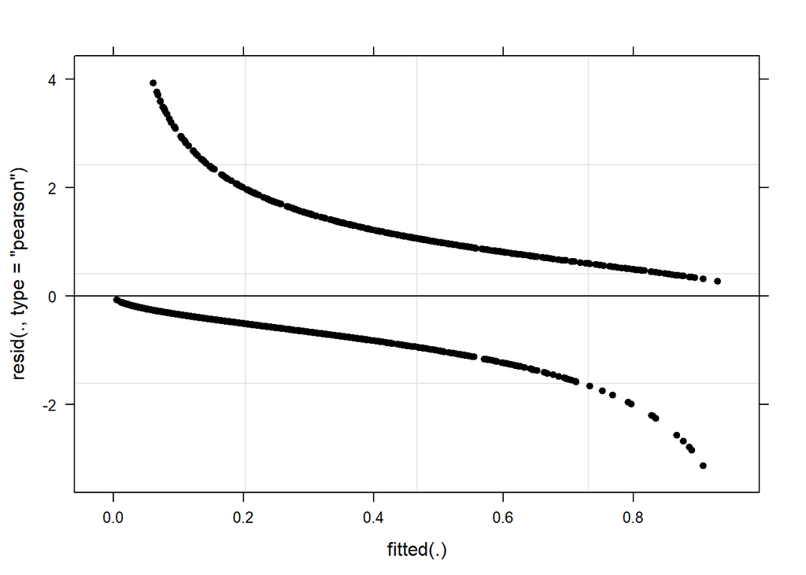

```r
plot(m58.glmer, col = "black", pch = 20); par(mfrow = c(1, 1))
```

## Model fitting summary

In a next step, we create a summary of the model fitting process.

```r
# use customized model comparison function
# create comparisons
m1m0 <- anova(m0.glmer, m1.glmer, test = "Chi")
m2m1 <- anova(m2.glmer, m1.glmer, test = "Chi")
m3m1 <- anova(m3.glmer, m1.glmer, test = "Chi")
m4m3 <- anova(m4.glmer, m3.glmer, test = "Chi")
m5m3 <- anova(m5.glmer, m3.glmer, test = "Chi")
m6m5 <- anova(m6.glmer, m5.glmer, test = "Chi")
m7m6 <- anova(m7.glmer, m6.glmer, test = "Chi")
m8m7 <- anova(m8.glmer, m7.glmer, test = "Chi")
m9m7 <- anova(m9.glmer, m7.glmer, test = "Chi")
m10m7 <- anova(m10.glmer, m7.glmer, test = "Chi")
m13m7 <- anova(m13.glmer, m7.glmer, test = "Chi")
m14m7 <- anova(m14.glmer, m7.glmer, test = "Chi")
m20m14 <- anova(m20.glmer, m14.glmer, test = "Chi")
m31m14 <- anova(m31.glmer, m14.glmer, test = "Chi")
m33m14 <- anova(m33.glmer, m14.glmer, test = "Chi")
m34m14 <- anova(m34.glmer, m14.glmer, test = "Chi")
m35m14 <- anova(m35.glmer, m14.glmer, test = "Chi")
m36m14 <- anova(m36.glmer, m14.glmer, test = "Chi")
m37m14 <- anova(m37.glmer, m14.glmer, test = "Chi")
m41m14 <- anova(m41.glmer, m14.glmer, test = "Chi")
m44m41 <- anova(m44.glmer, m41.glmer, test = "Chi")
m50m41 <- anova(m50.glmer, m41.glmer, test = "Chi")
m58m41 <- anova(m58.glmer, m41.glmer, test = "Chi")
m59m58 <- anova(m59.glmer, m58.glmer, test = "Chi")
m64m58 <- anova(m64.glmer, m58.glmer, test = "Chi")
# create a list of the model comparisons
mdlcmp <- list(m1m0, m2m1, m3m1, m4m3, m5m3, m6m5, m7m6, m8m7, m9m7, m10m7, m13m7, m14m7,
               m20m14, m31m14, m33m14, m34m14, m35m14, m36m14, m37m14, m41m14, m44m41,
               m50m41, m58m41, m59m58, m64m58)
# load function
source("D:\\R/ModelFittingSummarySWSU.R") # for Mixed Effects Model fitting (step-wise step-up): Binary Logistic Mixed Effects Models
# apply function
mdl.cmp.glmersc.swsu.dm <- mdl.fttng.swsu(mdlcmp)
# save comparisons to disc
write.table(mdl.cmp.glmersc.swsu.dm, here::here("data", "mdl_cmp_glmersc_swsu_reallywscnew.txt"), sep="\t")
# inspect output
mdl.cmp.glmersc.swsu.dm
```

```
##        Model
## 1   m1.glmer
## 2   m2.glmer
## 3   m3.glmer
## 4   m4.glmer
## 5   m5.glmer
## 6   m6.glmer
## 7   m7.glmer
## 8   m8.glmer
## 9   m9.glmer
## 10 m10.glmer
## 11 m13.glmer
## 12 m14.glmer
## 13 m20.glmer
## 14 m31.glmer
```

[output cut: 89 more lines]

## Model Summary

```r
m58.glm <-  glm(really ~ Age + Priming + Type + Gender + SemanticCategory +
    Education + Age:Priming + Priming:Gender + Gender:Education,
    family = "binomial", data = reallywsc)
```

```r
# load function for regression table summary
source("D:\\R/meblr.summary.R")
# set up summary table
meblrm_ampwsc <- meblrm.summary(m0.glm, m58.glm, m0.glmer, m58.glmer, reallywsc$really)
# save results to disc
write.table(meblrm_ampwsc, here::here("data", "meblrm_ampwsc_really.txt"), sep="\t")
# inspect result summary
meblrm_ampwsc
```

```
##                                  Group(s) Variance Std. Dev.
## Random Effect(s)                Adjective      0.5      0.71
## Fixed Effect(s)                  Estimate      VIF OddsRatio CI(2.5%) CI(97.5%)
## (Intercept)                         -1.63                0.2     0.09      0.43
## Age30-39                            -0.33     1.28      0.72     0.52      0.99
## Age40+                               -1.3     1.27      0.27      0.2      0.37
## PrimingPrime                         0.66     2.89      1.94      1.2      3.13
## TypePrivate                          0.69     2.06         2     1.31      3.06
## TypePublic                          -0.07     2.03      0.93     0.54      1.61
## GenderWoman                          1.13     2.24      3.09     2.24      4.27
## SemanticCategoryDimension           -0.34     2.35      0.71     0.32       1.6
## SemanticCategoryHuman               -0.37     4.31      0.69     0.35      1.38
## SemanticCategoryOther               -1.08     2.71      0.34     0.16      0.74
## SemanticCategoryPhyProperty         -0.51     2.42       0.6     0.27      1.34
## SemanticCategoryValue               -0.21     3.06      0.81     0.38      1.71
## EducationUniversity                  0.29     3.06      1.33     0.93       1.9
## Age30-39:PrimingPrime               -0.56     1.34      0.57     0.24      1.34
## Age40+:PrimingPrime                 -1.98     1.27      0.14     0.06      0.34
## PrimingPrime:GenderWoman             0.61     2.92      1.84     1.01      3.35
## GenderWoman:EducationUniversity     -0.48     3.91      0.62      0.4      0.96
## Model statistics
## Number of Groups
## Number of cases in model
## Observed misses
## Observed successes
## Residual deviance
## R2 (Nagelkerke)
## R2 (Hosmer & Lemeshow)
## R2 (Cox & Snell)
## C
## Somers' Dxy
## AIC
## BIC
## Prediction accuracy
## Model Likelihood Ratio Test
##                                         L.R. X2      DF         Pr
## Random Effect(s)                         214.03       1          0
## Fixed Effect(s)                      Std. Error z value   Pr(>|z|)
## (Intercept)                                 0.4   -4.06          0
## Age30-39                                   0.16   -2.02     0.0433
```

[output cut: 50 more lines]

```
## Model statistics                           Value
## Number of Groups                             420
## Number of cases in model                    2344
## Observed misses                                0
## Observed successes                             0
## Residual deviance                        2448.27
## R2 (Nagelkerke)                            0.394
## R2 (Hosmer & Lemeshow)                     0.259
## R2 (Cox & Snell)                           0.287
## C                                          0.828
## Somers' Dxy                                0.656
## AIC                                      2484.27
## BIC                                      2587.95
## Prediction accuracy                          NA%
## Model Likelihood Ratio Test     sig: p < .001***
```

We also check the Anova summary to see if predictors, rather than individual predictor levels, are significant and to what extent.

```r
# load function
library(car)
meblrm_ampwsc_Anova <- Anova(m58.glmer, type = "III", test = "Chi")
# save results to disc
write.table(meblrm_ampwsc_Anova, here::here("data", "meblrm_ampwsc_Anova_really.txt") , sep="\t")
# inspect results in Anova style
meblrm_ampwsc_Anova
```

```
## Analysis of Deviance Table (Type III Wald chisquare tests)
##
## Response: really
##                    Chisq Df            Pr(>Chisq)
## (Intercept)      16.5078  1     0.000048450704377 ***
## Age              76.4516  2 < 0.00000000000000022 ***
## Priming           7.3436  1               0.00673 **
## Type             21.3850  2     0.000022714139545 ***
## Gender           47.1605  1     0.000000000006541 ***
## SemanticCategory 11.7183  5               0.03886 *
## Education         2.5036  1               0.11359
## Age:Priming      18.5346  2     0.000094463736442 ***
## Priming:Gender    3.9927  1               0.04570 *
## Gender:Education  4.6945  1               0.03026 *
## ---
## Signif. codes:  0 '***' 0.001 '**' 0.01 '*' 0.05 '.' 0.1 ' ' 1
```

Visualize effects

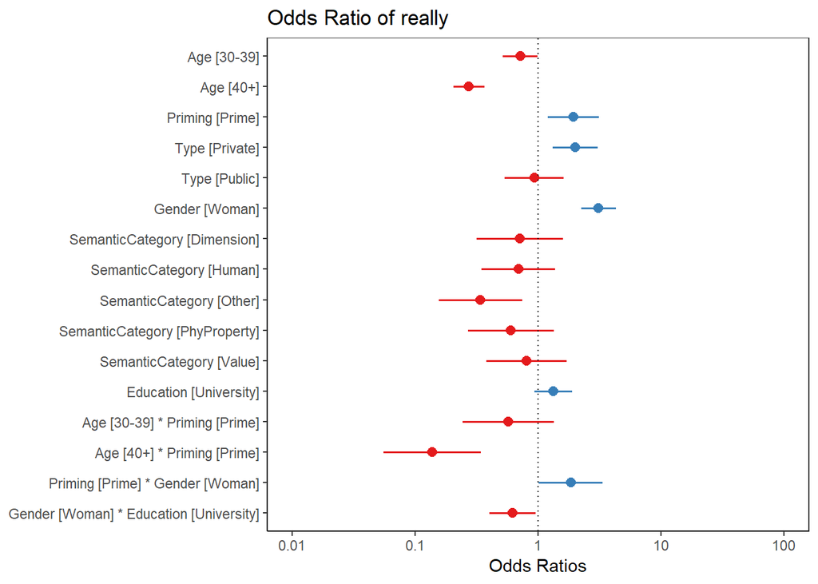

```r
sjPlot::plot_model(m58.glmer) +
  theme_bw() +
  geom_hline(yintercept = 1, linetype = "dotted") +
  theme(legend.position = "top",
        panel.grid.major = element_blank(),
        panel.grid.minor = element_blank(),
        axis.line = element_line(colour = "black")) +
  labs(title = "Odds Ratio of really")
```

```r
  ggsave(file =  here::here("images", "Effectsreally.png"),
         width = 20, height = 10, units = c("cm"),  dpi = 600)
```

```r
sjPlot::tab_model(m0.glmer, m58.glmer,
                  dv.labels = c("Intercept-only Model", "Final Minimal Model"))
```

|  | Intercept-only Model |  |  | Final Minimal Model |  |  |
| --- | --- | --- | --- | --- | --- | --- |
| Predictors | Odds Ratios | CI | p | Odds Ratios | CI | p |
| (Intercept) | 0.28 | 0.22 – 0.34 | **<0.001** | 0.20 | 0.09 – 0.43 | **<0.001** |
| Age30-39 |  |  |  | 0.72 | 0.52 – 0.99 | **0.043** |
| Age [40+] |  |  |  | 0.27 | 0.20 – 0.37 | **<0.001** |
| Priming [Prime] |  |  |  | 1.94 | 1.20 – 3.13 | **0.007** |
| Type [Private] |  |  |  | 2.00 | 1.31 – 3.06 | **0.001** |
| Type [Public] |  |  |  | 0.93 | 0.54 – 1.61 | 0.797 |
| Gender [Woman] |  |  |  | 3.09 | 2.24 – 4.27 | **<0.001** |
| SemanticCategory [Dimension] |  |  |  | 0.71 | 0.32 – 1.60 | 0.409 |
| SemanticCategory [Human] |  |  |  | 0.69 | 0.35 – 1.38 | 0.294 |
| SemanticCategory [Other] |  |  |  | 0.34 | 0.16 – 0.74 | **0.006** |
| SemanticCategory [PhyProperty] |  |  |  | 0.60 | 0.27 – 1.34 | 0.212 |
| SemanticCategory [Value] |  |  |  | 0.81 | 0.38 – 1.71 | 0.577 |
| Education [University] |  |  |  | 1.33 | 0.93 – 1.90 | 0.114 |
| Age30-39:PrimingPrime |  |  |  | 0.57 | 0.24 – 1.34 | 0.198 |
| Age [40+] * Priming [Prime] |  |  |  | 0.14 | 0.06 – 0.34 | **<0.001** |
| Priming [Prime] * Gender [Woman] |  |  |  | 1.84 | 1.01 – 3.35 | **0.046** |
| Gender [Woman] * Education [University] |  |  |  | 0.62 | 0.40 – 0.96 | **0.030** |
| Random Effects |  |  |  |  |  |  |
| σ<sup>2</sup> | 3.29 |  |  | 3.29 |  |  |
| τ<sub>00</sub> | 0.85 <sub>Adjective</sub> |  |  | 0.50 <sub>Adjective</sub> |  |  |
| ICC | 0.20 |  |  | 0.13 |  |  |
| N | 420 <sub>Adjective</sub> |  |  | 420 <sub>Adjective</sub> |  |  |
| Observations | 2344 |  |  | 2344 |  |  |
| Marginal R<sup>2</sup> / Conditional R<sup>2</sup> | 0.000 / 0.205 |  |  | 0.278 / 0.373 |  |  |

Inspect probabilities

```r
feffects <- names(fixef(m58.glmer))
loggedodds <- c(fixef(m58.glmer)[1],
          fixef(m58.glmer)[1] + fixef(m58.glmer)[2:length(fixef(m58.glmer))])
probs <- plogis(loggedodds)
ptb <- data.frame(feffects, probs)
ptb
```

```
##                                                        feffects      probs
## (Intercept)                                         (Intercept) 0.16399198
## Age30-39                                               Age30-39 0.12328147
## Age40+                                                   Age40+ 0.05089677
## PrimingPrime                                       PrimingPrime 0.27554173
## TypePrivate                                         TypePrivate 0.28202281
## TypePublic                                           TypePublic 0.15433531
## GenderWoman                                         GenderWoman 0.37762080
## SemanticCategoryDimension             SemanticCategoryDimension 0.12229496
## SemanticCategoryHuman                     SemanticCategoryHuman 0.11931396
## SemanticCategoryOther                     SemanticCategoryOther 0.06254388
## SemanticCategoryPhyProperty         SemanticCategoryPhyProperty 0.10526128
## SemanticCategoryValue                     SemanticCategoryValue 0.13677348
## EducationUniversity                         EducationUniversity 0.20710424
## Age30-39:PrimingPrime                     Age30-39:PrimingPrime 0.10089871
## Age40+:PrimingPrime                         Age40+:PrimingPrime 0.02624648
## PrimingPrime:GenderWoman               PrimingPrime:GenderWoman 0.26520807
## GenderWoman:EducationUniversity GenderWoman:EducationUniversity 0.10826031
```

Age

```r
library (multcomp)
summary(glht(m58.glmer, mcp(Age="Tukey")))
```

```
##
##   Simultaneous Tests for General Linear Hypotheses
##
## Multiple Comparisons of Means: Tukey Contrasts
##
##
## Fit: glmer(formula = really ~ (1 | Adjective) + Age + Priming + Type +
##     Gender + SemanticCategory + Education + Age:Priming + Priming:Gender +
##     Gender:Education, data = reallywsc, family = binomial, control = glmerControl(optimizer = "bobyqa"))
##
## Linear Hypotheses:
##                    Estimate Std. Error z value Pr(>|z|)
## 30-39 - 16-29 == 0  -0.3329     0.1648  -2.020    0.106
## 40+ - 16-29 == 0    -1.2969     0.1484  -8.737   <0.001 ***
## 40+ - 30-39 == 0    -0.9640     0.1899  -5.078   <0.001 ***
## ---
## Signif. codes:  0 '***' 0.001 '**' 0.01 '*' 0.05 '.' 0.1 ' ' 1
## (Adjusted p values reported -- single-step method)
```

```r
summary(glht(m58.glmer, mcp(SemanticCategory="Tukey")))
```

```
##
##   Simultaneous Tests for General Linear Hypotheses
##
## Multiple Comparisons of Means: Tukey Contrasts
##
##
## Fit: glmer(formula = really ~ (1 | Adjective) + Age + Priming + Type +
##     Gender + SemanticCategory + Education + Age:Priming + Priming:Gender +
##     Gender:Education, data = reallywsc, family = binomial, control = glmerControl(optimizer = "bobyqa"))
##
## Linear Hypotheses:
##                               Estimate Std. Error z value Pr(>|z|)
## Dimension - Difficulty == 0   -0.34205    0.41396  -0.826   0.9607
## Human - Difficulty == 0       -0.37012    0.35265  -1.050   0.8962
## Other - Difficulty == 0       -1.07848    0.39623  -2.722   0.0675 .
## PhyProperty - Difficulty == 0 -0.51127    0.40957  -1.248   0.8051
## Value - Difficulty == 0       -0.21353    0.38293  -0.558   0.9932
## Human - Dimension == 0        -0.02807    0.28772  -0.098   1.0000
## Other - Dimension == 0        -0.73643    0.33992  -2.166   0.2444
## PhyProperty - Dimension == 0  -0.16921    0.35571  -0.476   0.9968
## Value - Dimension == 0         0.12852    0.32414   0.397   0.9987
## Other - Human == 0            -0.70836    0.25993  -2.725   0.0668 .
## PhyProperty - Human == 0      -0.14114    0.28149  -0.501   0.9959
## Value - Human == 0             0.15659    0.23887   0.656   0.9858
## PhyProperty - Other == 0       0.56722    0.33419   1.697   0.5214
## Value - Other == 0             0.86495    0.29984   2.885   0.0429 *
## Value - PhyProperty == 0       0.29774    0.31943   0.932   0.9350
## ---
## Signif. codes:  0 '***' 0.001 '**' 0.01 '*' 0.05 '.' 0.1 ' ' 1
## (Adjusted p values reported -- single-step method)
```

## Check accuracy

We now check the prediction accuracy of the final minimal model.

```r
# predict probs of nativelike for effects
reallywsc$PredictedFrequency <- predict(m58.glmer, reallywsc, type="response")
# create response variable
reallywsc$PredictedResponse <- ifelse(reallywsc$PredictedFrequency > .5, "really", "other")
#summary(reallywscnew$PredictedResponse)
# load library
library(caret)
# create confusion matrix
confusionMatrix(as.factor(reallywsc$PredictedResponse), as.factor(reallywsc$really))
```

```
## Confusion Matrix and Statistics
##
##           Reference
## Prediction other really
##     other   1278    371
##     really   215    480
##
##                Accuracy : 0.75
##                  95% CI : (0.732, 0.7674)
##     No Information Rate : 0.6369
##     P-Value [Acc > NIR] : < 0.00000000000000022
##
##                   Kappa : 0.4373
##
##  Mcnemar's Test P-Value : 0.0000000001524
##
##             Sensitivity : 0.8560
##             Specificity : 0.5640
##          Pos Pred Value : 0.7750
##          Neg Pred Value : 0.6906
##              Prevalence : 0.6369
##          Detection Rate : 0.5452
##    Detection Prevalence : 0.7035
##       Balanced Accuracy : 0.7100
##
##        'Positive' Class : other
##
```

```r
# predict probs of nativelike for effects
reallywsc$PredictedFrequency <- predict(m1.glmer, reallywsc, type="response")
# create response variable
reallywsc$PredictedResponse <- ifelse(reallywsc$PredictedFrequency > .5, "really", "other")
#summary(reallywscnew$PredictedResponse)
# load library
library(caret)
# create confusion matrix
confusionMatrix(as.factor(reallywsc$PredictedResponse), as.factor(reallywsc$really))
```

```
## Confusion Matrix and Statistics
##
##           Reference
## Prediction other really
##     other   1205    345
##     really   288    506
##
##                Accuracy : 0.7299
##                  95% CI : (0.7115, 0.7478)
##     No Information Rate : 0.6369
##     P-Value [Acc > NIR] : < 0.0000000000000002
##
##                   Kappa : 0.4076
##
##  Mcnemar's Test P-Value : 0.02603
##
##             Sensitivity : 0.8071
##             Specificity : 0.5946
##          Pos Pred Value : 0.7774
##          Neg Pred Value : 0.6373
##              Prevalence : 0.6369
##          Detection Rate : 0.5141
##    Detection Prevalence : 0.6613
##       Balanced Accuracy : 0.7008
##
##        'Positive' Class : other
##
```

## C and Somers D

```r
pred_m0 <- ifelse(fitted(m0.glmer) >= .5, 1, 0)
pred_m1 <- ifelse(fitted(m1.glmer) >= .5, 1, 0)
pred_mf <- ifelse(fitted(m58.glmer) >= .5, 1, 0)
obs <- ifelse(reallywsc$really == "really", 1, 0)
somers2(obs, pred_m0)
```

```
##            C          Dxy            n      Missing
##    0.6507207    0.3014414 2344.0000000    0.0000000
```

```r
somers2(obs, pred_m1)
```

```
##            C          Dxy            n      Missing
##    0.7073495    0.4146990 2344.0000000    0.0000000
```

```r
somers2(obs, pred_mf)
```

```
##            C          Dxy            n      Missing
##    0.7328313    0.4656626 2344.0000000    0.0000000
```

## Visulaizing effects

```r
sjPlot::tab_model(m0.glmer, m1.glmer, m58.glmer,
                  dv.labels = c("Intercept-only Model", "Age-only Model", "Final Minimal Model"),
                  p.style = "stars", collapse.ci = TRUE)
```

Intercept-only Model

Age-only Model

Final Minimal Model

Predictors

Odds Ratios

Odds Ratios

Odds Ratios

(Intercept)

0.28 ***  
(0.22 – 0.34)

0.55 ***  
(0.45 – 0.68)

0.20 ***  
(0.09 – 0.43)

Age30-39

0.56 ***  
(0.42 – 0.74)

0.72 *  
(0.52 – 0.99)

Age [40+]

0.17 ***  
(0.13 – 0.22)

0.27 ***  
(0.20 – 0.37)

Priming [Prime]

1.94 **  
(1.20 – 3.13)

Type [Private]

2.00 **  
(1.31 – 3.06)

Type [Public]

0.93  
(0.54 – 1.61)

Gender [Woman]

3.09 ***  
(2.24 – 4.27)

SemanticCategory  
[Dimension]

0.71  
(0.32 – 1.60)

SemanticCategory [Human]

0.69  
(0.35 – 1.38)

SemanticCategory [Other]

0.34 **  
(0.16 – 0.74)

SemanticCategory  
[PhyProperty]

0.60  
(0.27 – 1.34)

SemanticCategory [Value]

0.81  
(0.38 – 1.71)

Education [University]

1.33  
(0.93 – 1.90)

Age30-39:PrimingPrime

0.57  
(0.24 – 1.34)

Age [40+] * Priming  
[Prime]

0.14 ***  
(0.06 – 0.34)

Priming [Prime] * Gender  
[Woman]

1.84 *  
(1.01 – 3.35)

Gender [Woman] *  
Education [University]

0.62 *  
(0.40 – 0.96)

Random Effects

σ<sup>2</sup>

3.29

3.29

3.29

τ<sub>00</sub>

0.85 <sub>Adjective</sub>

0.62 <sub>Adjective</sub>

0.50 <sub>Adjective</sub>

ICC

0.20

0.16

0.13

N

420 <sub>Adjective</sub>

420 <sub>Adjective</sub>

420 <sub>Adjective</sub>

Observations

2344

2344

2344

Marginal R<sup>2</sup> / Conditional R<sup>2</sup>

0.000 / 0.205

0.138 / 0.275

0.278 / 0.373

- p<0.05 ** p<0.01 *** p<0.001

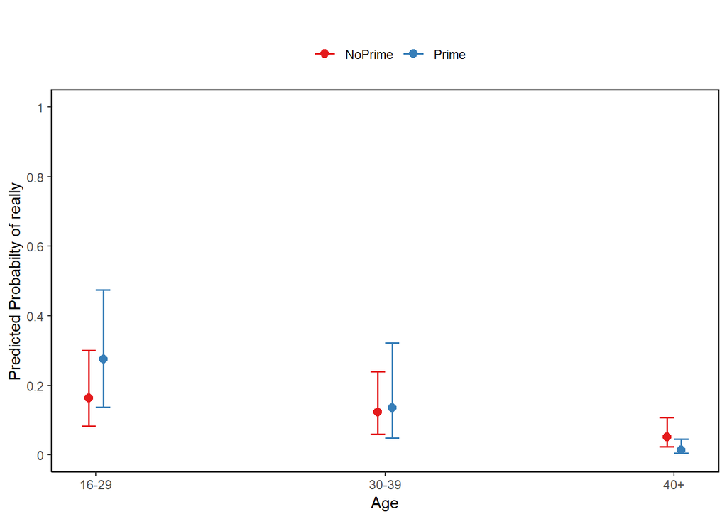

```r
sjPlot::plot_model(m58.glmer, type = "pred", terms = c("Age", "Priming")) +
  theme_bw() +
  theme(legend.position = "top",
        panel.grid.major = element_blank(),
        panel.grid.minor = element_blank(),
        axis.line = element_line(colour = "black"),
        legend.title = element_blank()) +
  scale_y_continuous(name = "Predicted Probabilty of really",
                     limits = c(0, 1),
                     breaks = seq(0, 1, .20),
                     labels = seq(0, 1, .20)) +
  labs(title = "") +
  ggsave(file =  here::here("images", "Effect_Age_Priming_really.png"),
         width = 7.5, height = 15, units = c("cm"),  dpi = 600)
```

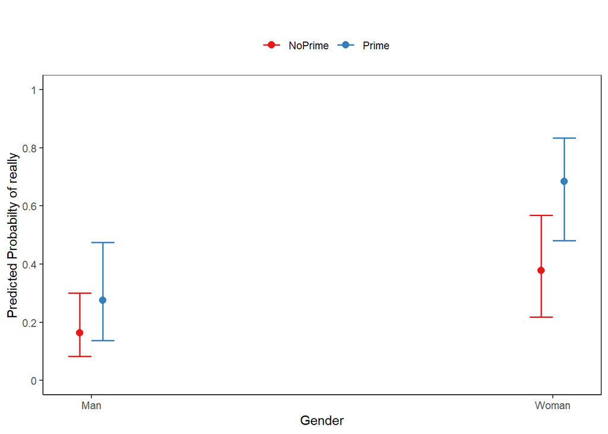

```r
sjPlot::plot_model(m58.glmer, type = "pred", terms = c("Gender", "Priming")) +
  theme_bw() +
  theme(legend.position = "top",
        panel.grid.major = element_blank(),
        panel.grid.minor = element_blank(),
        axis.line = element_line(colour = "black"),
        legend.title = element_blank()) +
  scale_y_continuous(name = "Predicted Probabilty of really",
                     limits = c(0, 1),
                     breaks = seq(0, 1, .20),
                     labels = seq(0, 1, .20)) +
  labs(title = "") +
  ggsave(file =  here::here("images", "Effect_Gender_Priming_really.png"),
         width = 7.5, height = 15, units = c("cm"),  dpi = 600)
```

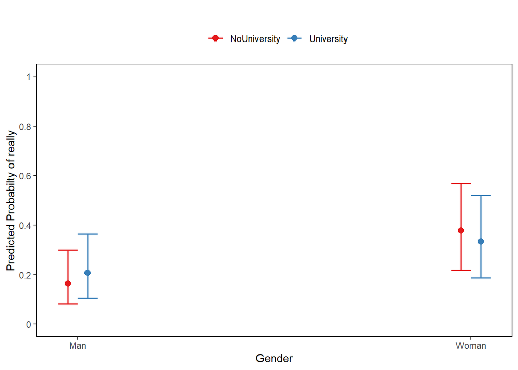

```r
sjPlot::plot_model(m58.glmer, type = "pred",
                   terms = c("Gender", "Education")) +
  theme_bw() +
  theme(legend.position = "top",
        panel.grid.major = element_blank(),
        panel.grid.minor = element_blank(),
        axis.line = element_line(colour = "black"),
        legend.title = element_blank()) +
  scale_y_continuous(name = "Predicted Probabilty of really",
                     limits = c(0, 1),
                     breaks = seq(0, 1, .20),
                     labels = seq(0, 1, .20)) +
  labs(title = "") +
  ggsave(file =  here::here("images", "Effect_Gender_Education_really.png"),
         width = 7.5, height = 15, units = c("cm"),  dpi = 600)
```

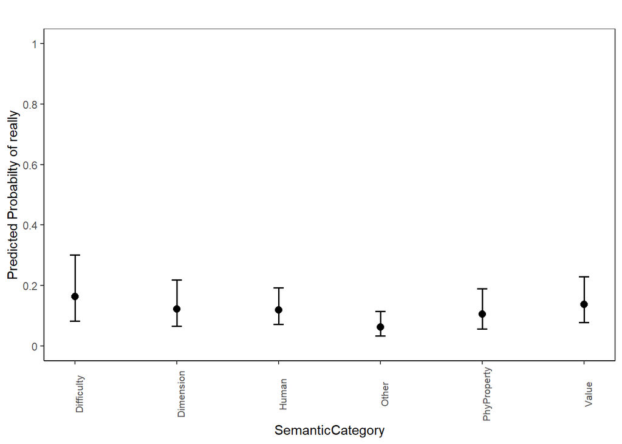

```r
sjPlot::plot_model(m58.glmer, type = "pred", terms = c("SemanticCategory")) +
  theme_bw() +
  theme(legend.position = "top",
        panel.grid.major = element_blank(),
        panel.grid.minor = element_blank(),
        axis.line = element_line(colour = "black"),
        axis.text.x = element_text(size=8, angle=90)) +
  scale_y_continuous(name = "Predicted Probabilty of really",
                     limits = c(0, 1),
                     breaks = seq(0, 1, .20),
                     labels = seq(0, 1, .20)) +
  labs(title = "") +
  ggsave(file =  here::here("images", "Effect_SemanticCategory_really.png"),
         width = 10, height = 10, units = c("cm"),  dpi = 600)
```

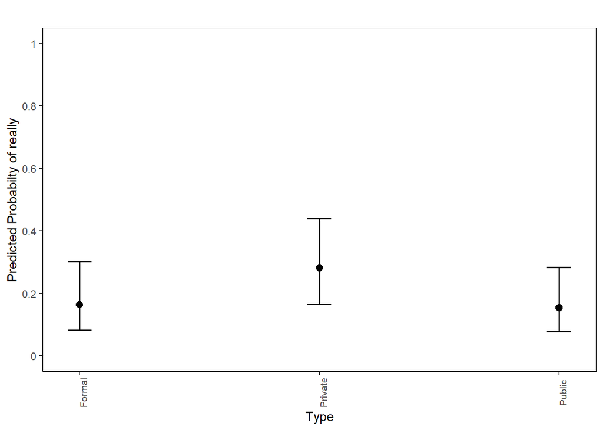

```r
sjPlot::plot_model(m58.glmer, type = "pred", terms = c("Type")) +
  theme_bw() +
  theme(legend.position = "top",
        panel.grid.major = element_blank(),
        panel.grid.minor = element_blank(),
        axis.line = element_line(colour = "black"),
        axis.text.x = element_text(size=8, angle=90)) +
  scale_y_continuous(name = "Predicted Probabilty of really",
                     limits = c(0, 1),
                     breaks = seq(0, 1, .20),
                     labels = seq(0, 1, .20)) +
  labs(title = "") +
  ggsave(file =  here::here("images", "Effect_Type_really.png"),
         width = 10, height = 10, units = c("cm"),  dpi = 600)
```

```r
randomtb <- ranef(m58.glmer)
rndmadj <- as.vector(unlist(randomtb$`Adjective`))
adj <- as.vector(unlist(rownames(randomtb$`Adjective`)))
rndmadjtb <- data.frame(adj, rndmadj)
colnames(rndmadjtb) <- c("Adjective", "Intercept")
rndmadjtb <- rndmadjtb[order(rndmadjtb$Intercept, decreasing = T),]
# inspect
head(rndmadjtb)
```

```
##       Adjective Intercept
## 154       great 1.3249514
## 409       weird 1.0434716
## 151        good 1.0257486
## 66         cool 0.9506459
## 234        nice 0.8696186
## 193 interesting 0.8153730
```

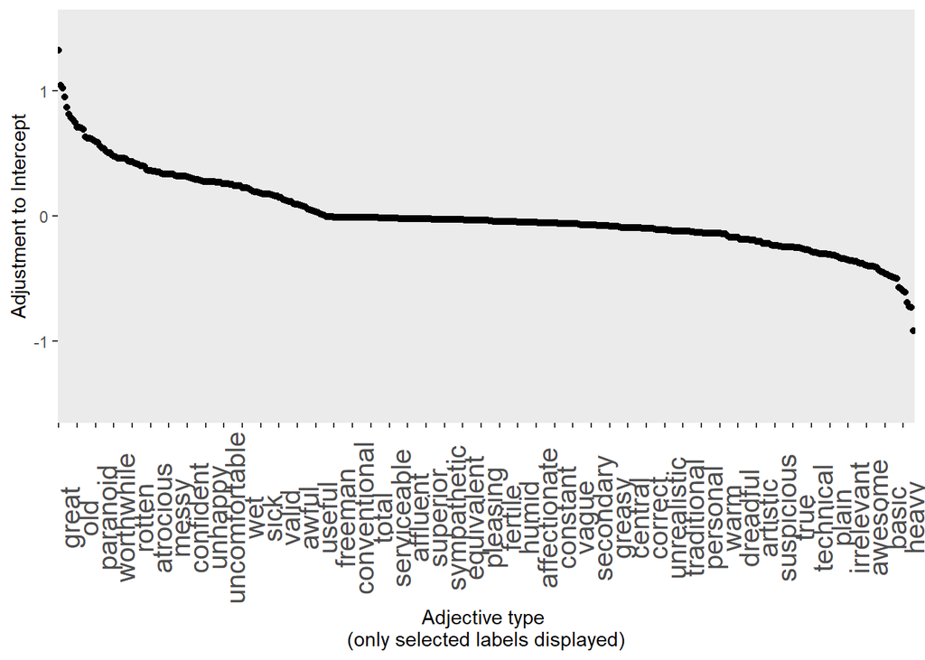

```r
ggplot(rndmadjtb, aes(Adjective, Intercept)) +
  geom_point(aes(reorder(Adjective, -Intercept, fun = Intercept), y=Intercept)) +
  coord_cartesian(ylim = c(-1.5, 1.5)) +
  theme_set(theme_bw(base_size = 15)) +
  theme(legend.position="none",
        axis.text.x = element_text(size=15, angle=90),
        panel.grid.major = element_blank(),
        panel.grid.minor = element_blank()) +
  scale_x_discrete(breaks = rndmadjtb$Adjective[seq(1,length(rndmadjtb$Adjective),9)]) +
  labs(x = "Adjective type \n(only selected labels displayed)", y = "Adjustment to Intercept") +
  ggsave(file = here::here("images", "RandomEffects_Adjective_really.png"),
       height = 5,  width = 7.5,  dpi = 320)
```

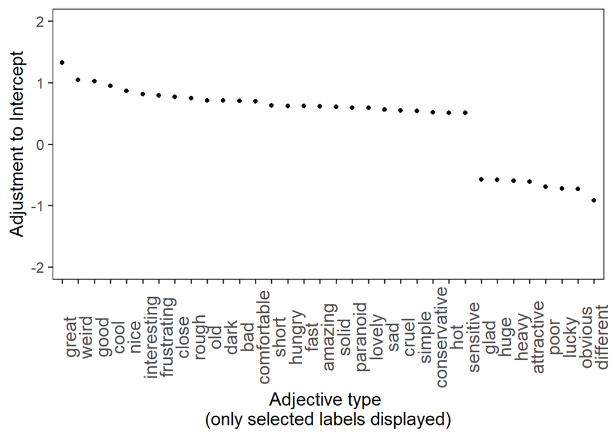

```r
rndmadjtb %>%
  dplyr::filter(Intercept > .5 | Intercept < -.5) %>%
  ggplot(aes(Adjective, Intercept)) +
  geom_point(aes(reorder(Adjective, -Intercept, fun = Intercept), y=Intercept)) +
  coord_cartesian(ylim = c(-2, 2)) +
  theme_set(theme_bw(base_size = 15)) +
  theme(legend.position="none",
        axis.text.x = element_text(size=15, angle=90),
        panel.grid.major = element_blank(),
        panel.grid.minor = element_blank()) +
  labs(x = "Adjective type \n(only selected labels displayed)", y = "Adjustment to Intercept") +
  ggsave(file = here::here("images", "RandomEffects_Adjective_redux_really.png"),
       height = 5,  width = 7.5,  dpi = 320)
```

# Citation & Session Info

Schweinberger, Martin. 2021. *On the waning of forms - a corpus-based analysis of losers in language change (Part 4)*. Brisbane: The University of Queensland. url: https://slcladal.github.io/isle6verynze.html (Version 2021.05.17).

```
@manual{schweinberger2021isle6verynze,
  author = {Schweinberger, Martin},
  title = {On the waning of forms - a corpus-based analysis of losers in language change (Part 4)},
  note = {https://slcladal.github.io/isle6verynze.html},
  year = {2021},
  organization = {The University of Queensland, School of Languages and Cultures},
  address = {Brisbane},
  edition = {2021.05.17}
}
```

Back to top

# References

Chen, Henian, Patricia Cohen, and Sophie Chen. 2010. “How Big Is a Big Odds Ratio? Interpreting the Magnitudes of Odds Ratios in Epidemiological Studies.” *Communications in Statistics—Simulation and Computation* 39 (4): 860–64.